# beatochess no. 01 (March 2024)

Beat Neuenschwander, email: neuenschwander.beat@gmail.com

This is the first issue of **beatochess**.

I am currently going through the studies by **Zakhodyakin** in Harold van der Heijden’s **HHdbVI** database.

I am also looking at some older studies published in **Shakhmatny Listok**.

In this issue, you find a few comments, new cooks, and revisions.

# Recent studies

## Chess Study Art 2022

File: Neuenschwander-2022-ChessStudyArt.pgn

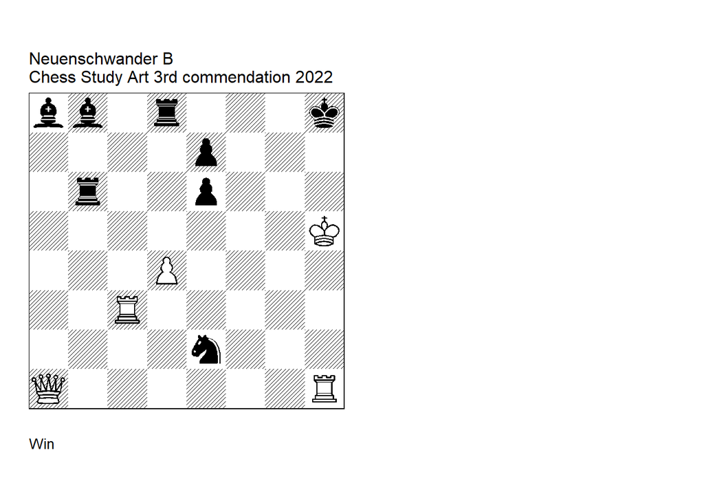

GBR: +1863.12h5h8 FEN: bb1r3k/4p3/1r2p3/7K/3P4/2R5/4n3/Q6R w - - 0 1

**1. Kg6+** (1. Rc6 Rg8! (1… Bxc6 2. Kg6+ Kg8 3. Rh8+ Kxh8 4. d5+ e5 5. Qh1+) 2. d5+ Kh7 (2… e5 3. Rxb6) 3. Rxb6 Ng3+ 4. Kh4 Nf5+ = ) **1… Kg8 2. Rh8+** ( 2. Qxa8 e5+ = ) **2… Kxh8 3. Kf7 Ng3** (3… Bg3 4. Rc8 (4. d5 Bxd5 5. Rxg3+ e5+) (4. Rc6 Rb1) 4… Bd5 (4… Be4 5. Qa5 Bf5 6. Rxd8+) 5. Rxd8+ Kh7 6. Qa3 Be4 7. Qxe7 Rb7 8. Rd7 Rxd7 9. Qxd7 and White wins more material quickly ) (3… Nxc3 4. Qg1 (4. Qe1 Rf8+ 5. Kxf8 Kh7 6. Kf7 e5) (4. Qf1 Rf8+ 5. Kxf8 Kh7 6. Kf7 Kh6) ) **4. Rxg3** (4. Qxa8 Rb5 5. Rxg3 Rf5+ 6. Kxe6 Rf6+ 7. Kxe7 Bxg3 8. Qxd8+ Kg7 =tablebase ) (4. d5 Bxd5 5. Rxg3+ e5+) (4. Qf1 Be4) **4… Bxg3 5. Qd1** (5. d5+ Rb2 6. Qxb2+ e5 and Lxd5+= ) **5… Rb5** (5… Be4 6. Qg4) **6. d5 Rdxd5 7. Qa1+** (7. Qh1+ (loss of time) 7… Bh2 8. Qa1+ Be5 = main variation ) **7… Be5** (7… Re5 8. Qxa8+) **8. Qc1 Bg7 9. Qh1+** (9. Qc8+ Kh7 10. Qg8+ Kh6 11. Qxg7+ Kh5) **9… Rh5 10. Qxa8+ Kh7 11. Qg8+ Kh6 12. Qxg7 1-0**.

## Die Schwalbe 2023

File: Neuenschwander-2023-Schwalbe-A.pgn

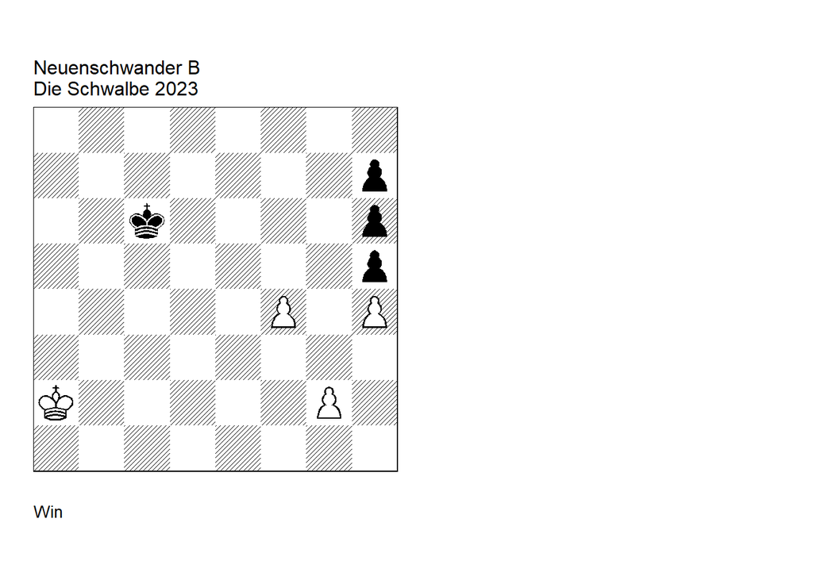

GBR: +0000.33a2c6 FEN: 8/7p/2k4p/7p/5P1P/8/K5P1/8 w - - 0 1

**1. Kb3** (1. Ka3? Kc5 2. Ka4 Kd5 3. Ka5 Ke6 = ) **1… Kd6 2. Kb4** (2. Kc4? Ke7 (2… Ke6? 3. Kc5 Kf5 4. g3 Ke6 5. Kc6) 3. Kd5 Kf6 4. Ke4 Ke6 5. f5+ Kf6 6. Kf4 Ke7 7. Ke5 Kf7 8. f6 Kg6 9. g4 (9. Ke6) 9… Kf7 (9… hxg4? 10. Ke6) 10. gxh5 Kf8 11. Ke6 Ke8 12. f7+ Kf8 13. Kf6) **2… Kd5 3. Ka4 Zugzwang.** (3. Kb5? Ke4 4. g3 Kd5) (3. Ka5? Ke6 (3… Ke4? 4. g3 Kf5 5. Kb5) 4. Kb6 Kf5 5. g3 Kf6 = ) **3… Ke6** (3… Ke4 4. g3 Kd5 5. Kb5 Kd6 6. Kb6) (3… Kd4 4. Ka5 Ke4 5. g3 Kf5 6. Kb5 Kf6 7. Kb6) **4. Ka5** (4. Kb5? Kf6 5. Kc6 (5. Kb6 Kf5 6. g3 Kf6) 5… Kf5 6. g3 Ke6) **4… Kf5 5. g3 Kg6** (5… Kf6 6. Kb6) **6. Ka6 Kg7 7. Ka7 Kg6!** (7… Kf7 8. Kb7 Ke7 9. Kc7 Ke6 10. Kd8 Kf7 11. Kd7 Kf6 12. Ke8) **8. Kb8! Kf6 9. Kc8 Ke6 10. Kd8 Kf6 11. Ke8 Ke6 12. Kf8 Kf6 13. Kg8 1-0**.

File: Neuenschwander-2023-Schwalbe-B.pgn

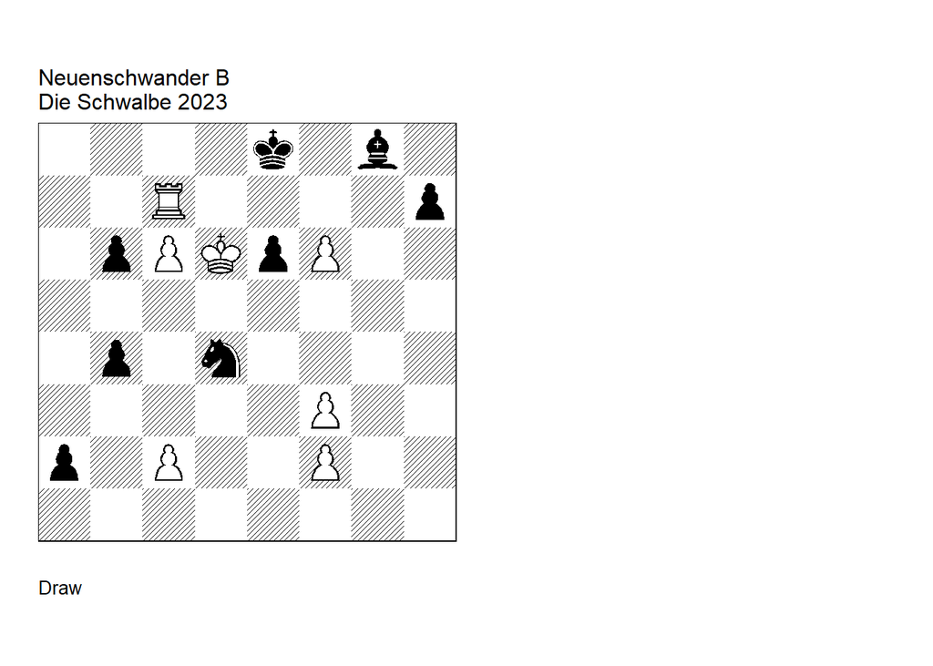

GBR: =0133.55d6e8 FEN: 4k1b1/2R4p/1pPKpP2/8/1p1n4/5P2/p1P2P2/8 w - - 0 1

**1. Rc8+** (1. f7+? Kf8 2. fxg8=Q+ Kxg8 3. Rc8+ Kf7 4. Ra8 Nb5+ 5. Kd7 Na3 6. c7 a1=Q 7. c8=Q Qd1+ 8. Kc6 Qxc2+ 9. Kd7 Qxc8+ 10. Kxc8 h5) **1… Kf7 2. Ra8 Nb5+ 3. Ke5 Na3 4. Ra7+ Kg6** (4… Ke8 5. Ra8+) **5. Rg7+ Kh5 6. Rg1 Nb1 7. Rh1+ Kg6 8. Rg1+ Kf7 9. Rg7+ Kf8 10. Ra7 Na3 11. Ra8+ Kf7 12. Ra7+ Kg6 13. Rg7+ Kh5 14. Rg1 positionelles Remis 1/2-1/2**.

## Magyar Sakkvilag 2023

File: Neuenschwander-2023-MagyarSakkvilag.pgn

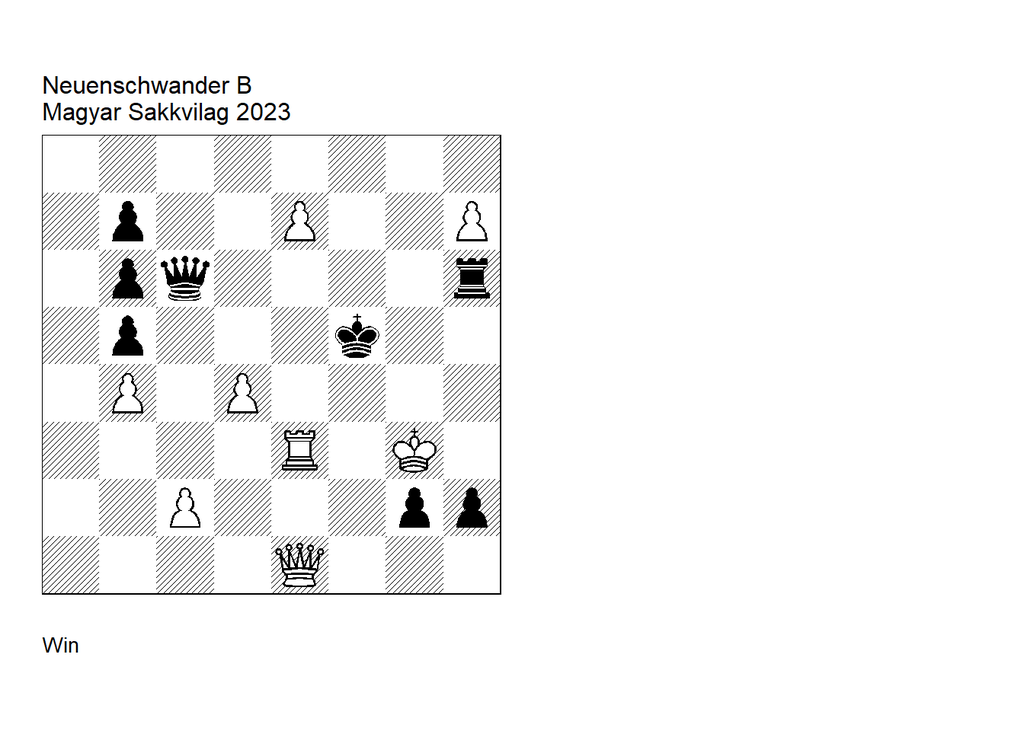

GBR: +4400.55g3f5 FEN: 8/1p2P2P/1pq4r/1p3k2/1P1P4/4R1K1/2P3pp/4Q3 w - - 0 1

**1. Re5+** (1. Rf3+? Qxf3+ 2. Kxf3 g1=N+! 3. Ke3 Rh3+ (3… Re6+? 4. Kf2 Nh3+ 5. Kg3 Rxe1 6. Kxh2 favors White ) 4. Kf2 h1=Q 5. Qe5+ Kg4 and White has not more than perpetual check ) **1… Kg6** (1… Kf6 2. Qf2+) **2. e8=Q+** (2. Qe4+ Qxe4 3. e8=Q+ Kxh7 = ) **2… Qxe8 3. Qe4+ Kg7** (3… Kf6 4. Rf5+ (4. Qf4+ Kg7 5. h8=Q+ Rxh8 6. Rg5+ Qg6 7. Rxg6+ Kxg6 = ) 4… Kg7 5. Rg5+ Qg6 6. Rxg6+ Rxg6+ 7. Qxg6+ Kxg6 =main variation ) (3… Kf7 4. Qd5+? (4. Rf5+ Kg7 =main variation ) 4… Kg7 5. Rg5+ (5. Qxb7+ Qf7 6. Rg5+ Kh8 7. Qa8+ Kxh7 8. Qe4+ = ) 5… Rg6 6. Qg8+ Qxg8 7. hxg8=Q+ Kxg8 8. Rxg6+ Kh7 9. Kxh2 Kxg6 10. Kxg2 Kf6 ! 11. Kf2 Ke6 = ) **4. Rg5+ Qg6** (4… Rg6 5. h8=Q+) **5. Rxg6+ Rxg6+ 6. Qxg6+ Kxg6 7. h8=N+!** (7. Kxg2 ? 7… Kxh7 8. Kxh2 Kg6 9. Kg3 (9. Kg2 Kf6 ! 10. Kf3 Kf7 ! ) 9… Kg7 ! 10. Kg4 Kg6 11. Kf4 Kf6 12. Ke4 Ke6 13. c3 Kd6 14. Kd3 Kd5) (7. Kxh2 ? 7… Kxh7 8. Kxg2 Kg6 = ) **7… Kh7** (7… Kg7 8. Kxg2 (8. Kxh2 Kxh8 9. Kxg2 Kg8 = ) 8… Kxh8 (8… h1=Q+ 9. Kxh1 Kxh8) 9. Kxh2 zugzwang ) **8. Kxg2** (8. Kxh2 Kxh8 9. Kxg2 Kg8 = ) **8… Kg7 9. Kh1!** ( 9. d5 ? 9… Kf6 = ) (9. Kxh2 ? 9… Kxh8 10. Kh3 Kh7) **9… Kxh8 10. Kxh2 Kg8 11. Kg2 Kf8 12. Kh3!** (12. Kg3? Kg7 = ) (12. Kf3? Kf7 = ) ( 12. Kf2? breaks the vertical opposition, but the wK is not advanced far enough 12… Ke7 13. Ke3 Kd6 14. Ke4 Ke6 15. d5+ Kd6 16. Kd4 Ke7 ( or 16… Kc7) 17. Ke5 Kd7 18. d6 Kc6 19. c4 (19. Ke6 stalemate ) 19… Kd7 20. cxb5 Kd8) **12… Kf7** (12… Ke8 13. Kg3! (13. Kg4? Ke7 14. Kg5 Ke6 15. Kg6 Kd5 16. c3 Ke6) 13… Ke7 14. Kg4! Ke6 15. Kg5! Kd5 16. c3 Kc6 17. Kg6) **13. Kh4 Kf8 14. Kh5** (14. Kg4 ? 14… Kg8 = ) **14… Kf7 15. Kh6 1-0**.

## Ceskoslovensky Sach 2023

File: Neuenschwander-2023-CeskoslovenskySach.pgn

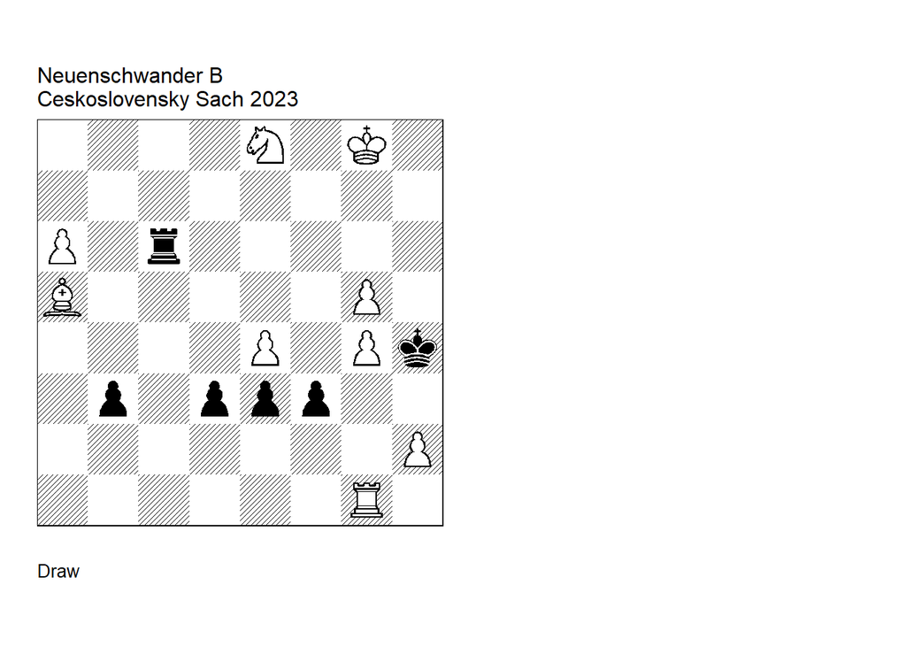

GBR: =041154g8h4) FEN: 4N1K1/8/P1r5/B5P1/4P1Pk/1p1ppp2/7P/6R1 w - - 0 1

**1. Nc7** ( After 1. a7? Rc8! White cannot equalize, for example 2. g6 f2 3. Rf1 Rxe8+ 4. Kh7 Ra8 5. g7 Rxa7 6. Bb6 Rxg7+ 7. Kxg7 e2 8. Bxf2+ Kh3 9. Rb1 d2 10. Rxb3+ Kxh2 and now 11. Rb5 e1=Q 12. Bxe1 dxe1=Q leads to a technically won endgame for Black (tablebase); other rook moves to b6 or b8 do not change the evaluation. ) **1… f2 2. Rf1 Rc5** (2… Rxc7 3. Bxc7 e2 4. Rxf2 e1=Q 5. g6 d2 6. a7 Qxe4 7. Rxd2 Qxg6+ 8. Kf8 =) (2… Rxa6 3. Nxa6 e2 4. Rxf2 b2 5. Nc5 b1=Q 6. g6 =) **3. Bd2 exd2** (3… Rxg5+ 4. Kf8 exd2 5. a7 =main variation ) **4. a7 Rxg5+** (4… Rc1? 5. Rxf2 d1=Q 6. a8=Q is better for White ) **5. Kf8! First thematic square differentiation** (wKf8/f7) **.** ( After the thematic 5. Kf7? , as in the main line, 5… Ra5 6. a8=Q Rxa8 7. Nxa8 Kh3 8. Rd1 Kg2 9. Rxd2 Kg1 10. Rd1+ f1=Q+ 11. Rxf1+ Kxf1 12. Nb6 d2 13. Nc4 Ke2 14. Nb2 d1=Q 15. Nxd1 Kxd1 16. e5 b2 17. e6 b1=Q 18. e7 Black, having a check on a2, b3, or h7, wins ) **5… Ra5 6. a8=Q Rxa8+ 7. Nxa8 Kh3** (7… Kxg4 8. Nb6 Kf3 9. Nc4 Ke2 10. Nxd2 Kxd2 11. Rxf2+ Ke1 12. Rg2! is equal ) **8. Rd1 Kg2 9. Rxd2 Kg1 10. Rd1+! Second thematic square differentation** (bKf1/f2) **.** ( After the thematic 10. Rxf2? Kxf2 White cannot eliminate one of the black pawns ) **10… f1=Q+ 11. Rxf1+ Kxf1 12. Nb6 d2 13. Nc4 Ke2 14. Nb2! Third thematic square differentiation** (bKd1/d2) **.** ( After the thematic 14. Nxd2? Kxd2 15. e5 b2 16. e6 b1=Q 17. e7 Black wins after the check 17… Qf1+ ! ) **14… d1=Q 15. Nxd1 Kxd1 16. e5 b2 17. e6 b1=Q 18. e7 Qb4 19. h3! The final position is known: M. Fabbri, L’Italia Scacchistica/2** (EG 01669) **. U2: Campioli=M HHdbIII 31641 4-12-2002. 1/2-1/2**.

## Schweizerische Schachzeitung 2023

File: Neuenschwander-2023-SSZ.pgn

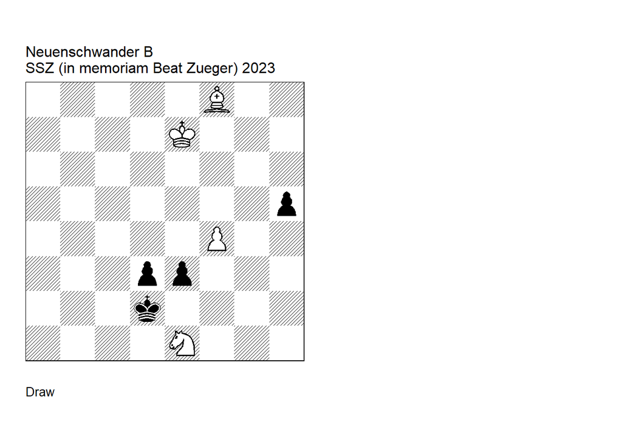

GBR: =0011.13e7d2 FEN: 5B2/4K3/8/7p/5P2/3pp3/3k4/4N3 w - - 0 1

**1. Ng2 h4** (1… Ke2 2. f5 d2 3. Nxe3 =) **2. Nxh4** (2. f5? 2… h3 3. Nxe3 Ke2!! 4. Nd5 h2 5. Nf4+ Ke3 6. Nxd3 h1=Q 7. Nc5 Kf4 8. f6 Kf5 9. Bg7 Qd5 10. Nd7 Qe6+ -+) **2… Kc3** (2… Kc2 3. Ng2 e2 4. Ne1+! Kc3 5. Bg7+! Kc4 6. Nf3! e1=Q+ 7. Nxe1 d2 8. Nf3 d1=Q 9. Nd4) **3. Bg7+!** (3. f5 d2 4. Bg7+ Kc4 5. f6 e2 (5… d1=Q? 6. f7 e2 7. Nf3 =) 6. Nf3 e1=Q+ 7. Nxe1 dxe1=Q+ 8. Kf8 Kd5 -+) **3… Kc4 4. Bc3!! Kxc3 5. Nf3 d2** ( main 5… e2 6. f5 d2 7. f6 e1=Q+ (7… d1=Q 8. f7 =) 8. Nxe1 dxe1=Q+ 9. Kf8 =) **6. Nxd2!! exd2** ( main 6… Kxd2 7. f5 e2 8. f6 e1=Q+ 9. Kf8 =) **7. f5 d1=Q 8. f6 Qe1+ 9. Kf8 1/2-1/2**.

## Pat A Mat 2023

File: Neuenschwander-2023-PatAMat.pgn

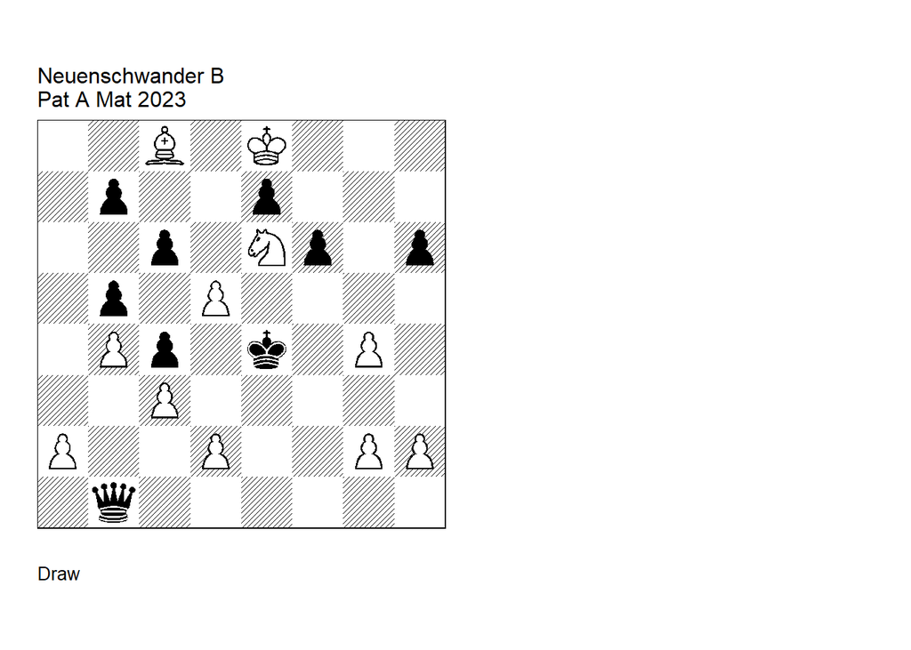

GBR: =3011.87e8e4 FEN: 2B1K3/1p2p3/2p1Np1p/1p1P4/1Pp1k1P1/2P5/P2P2PP/1q6 w - - 0 1

**1. d6 exd6 2. Nf8 Qe1** (2… Qxa2 3. Bf5+ Kd5 4. Ng6 Qxd2 5. Ne7+ Ke5 6. Ng6+) **3. Bf5+ Kf4+ 4. Ne6+ Two consecutive cross-checks** (B-K-N) **. 4… Ke5 5. Nf8 Kf4+ 6. Ne6+ Single cross-check** (K-N) **. 6… Ke5 7. Nf8 Kd5+** (7… d5 8. Kd7 d4 9. Ng6+ Kd5 10. Ne7+) **8. Be6+ Single crosscheck** (K-B) **. 8… Ke4** (8… Qxe6+ 9. Nxe6 Kxe6 =) **9. Bf5+ Kd5+ 10. Be6+ Two consecutive cross-checks** (B-K-B) **. 10… Ke5 11. Bf5 c5 12. Ng6+ Kd5+ 13. Ne7+ Two consecutive cross-checks** (N-K-N) **. 13… Ke5 14. Ng6+ perpetual check. 1/2-1/2**.

## Schach 2023

File: Neuenschwander-2023-Schach.pgn

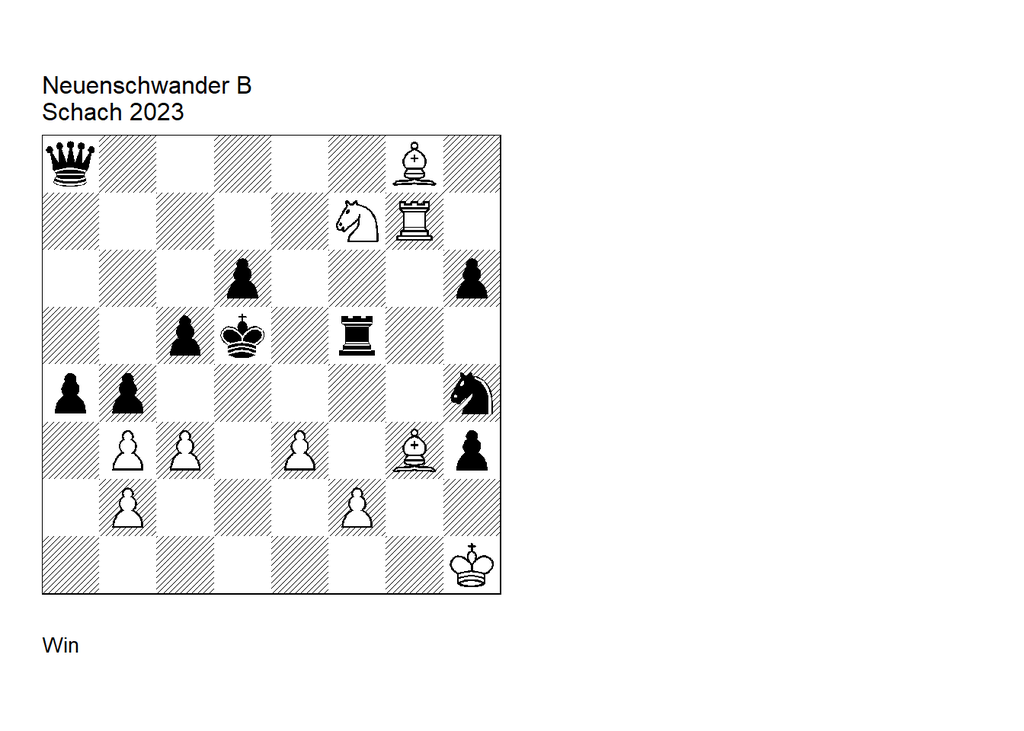

GBR: +3424.56h1d5 FEN: q5B1/5NR1/3p3p/2pk1r2/pp5n/1PP1P1Bp/1P3P2/7K w - - 0 1

**1. Ne5+ Ke4** (1… Qxg8 2. c4+ Ke4 3. Rxg8 dxe5 4. Bxh4) **2. Rg4+ Rf4 3. Rxf4+ Kxe5+ cross-check 4. e4 Nf5** (4… Qxg8 5. Rg4+) **5. Rxf5+** (5. Bd5? Nxg3+ 6. fxg3 Qxd5! 7. exd5 bxc3 8. bxc3 axb3 9. Kh2 Kxd5 10. c4+ Ke5 11. Rf3 d5 12. Rxb3 dxc4) **5… Kxe4 6.Bh7 Kd3+ 7. Rd5+ cross-check Ke2 8. Bd3+** (8. Be4? a3) **8… Kf3** (8… Kd1 9. Be4+ Kc1 (9… Ke2 10. bxa4) 10. Bf4+ Kxb2 11. Rd2+) (8… Ke1 9. Bc4 Qg8 10. Rd1+) **9. Rf5+ Kg4+ cross-check 10. Be4 Qxe4+ 11. f3+ cross-check 11… Kxf5 12. fxe4+ Four cross-checks and king round trip** (e4-d3-e2-f3-g4-f5-e4) **. 1-0**.

## EG 2023

Published in: EG July 2023.

File: Neuenschwander-2023-EG-233.pgn

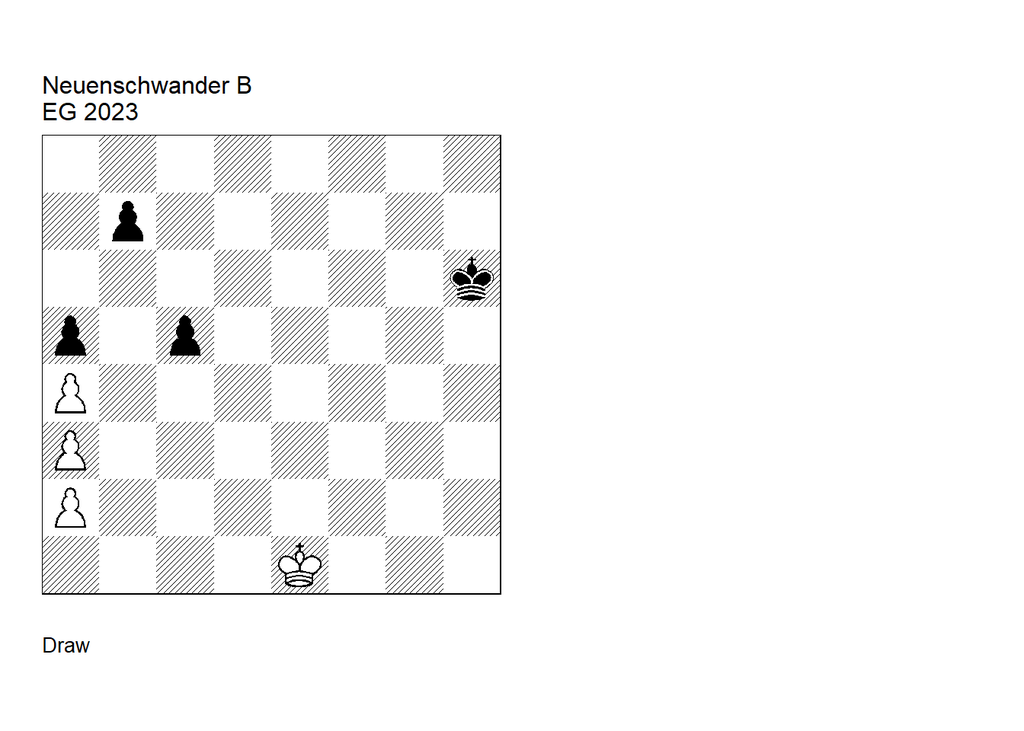

GBR: =0000.33e1h6 FEN: 8/1p6/7k/p1p5/P7/P7/P7/4K3 w - - 0 1

**1. Kd1** (Black has a strong passed pawn and a tempo in reserve, b7-b6. White has two resources. First, the position with wKd2 and bKd4, White draws by 1. Kc2 c3 2. Kb3 Kd3 stalemate, or 2….b5 3.Kc2 bxa4 3.Kd1 c2+ 4.Kc1 Kc3 stalemate. Second, White can steal Black’s tempo by moving the wK to c4, although White must then be careful not to lose the horizontal opposition. White draws by respecting the following corresponding squares (wK/bK with Black to move), depending on whether the black pawn is on b7 or b6. Corresponding squares with bPb7: d5/d3, e5/c2, f5/c4,b2,d2, g5/c4,c2, h5/c4,e4,b2,d2, d4/d2, e4/c3,e2, f4/b3,d3, g4/c3, h4/b3,d3. Corresponding squares with bPb6: e3/c3, f3/b3,d3, g3/c3,e3, h3/b3,d3,f3, e2/c2, f2/b2,d2, g2/c2,e2, h2/b2,d2,f2. In the following, all moves are only moves if not mentioned otherwise.) (1. Kd2? Kh5 2. Kd3 Kh4 3. Kc4 b6 4. Kb3 Kh3 5. Kb2 Kh2 6. Kc2 (6. Kc3 Kg1 (or Kg3) ) 6… Kg2) (1. Ke2? Kg5) (1. Kf2? Kh5) **1… Kg6 2. Kc1** (2. Kc2? Kg5) (2. Kd2? Kf5) (2. Ke2? Kg5) **2… Kg5** (2… Kf6 3. Kd1 (or Kb1) 3… Ke5 4. Kc2 Kd4 5. Kd2 c4 6. Kc2 c3 7. Kb3 b5 (7… Kd3 stalemate ) 8. Kc2 (8. axb5? Kd3) 8… bxa4 9. Kc1 Kd3 10. Kd1 c2+ 11. Kc1 Kc3 stalemate ) **3. Kc2** (3. Kb2? Kf5) (3. Kd2? Kf5) **3… Kg4** (3… Kf5 4. Kd2 (or Kb2) ) (3… Kf4 4. Kd3 (or Kb3) ) (3… Kh4 4. Kd3 (or Kb3) ) **4. Kc3** (4. Kd3? Kf4 (or Kh4) ) **4… Kg3** (4… Kf3 5. Kc4 b6 6. Kd3 (or Kb3) ) (4… Kh3 5. Kc4 b6 6. Kd3 (or Kb3) ) **5. Kc4 Stealing Black’s tempo and keeping the horizontal opposition with next move. 5… b6 6. Kc3 Kg2 7. Kc2 Kg1 8. Kc1 1/2-1/2**.

## EG 2024

Published in: EG Jan 2024.

File: Neuenschwander-2024-EG-235.pgn

The main idea of the study is stepping in front of the passed pawn (5.Kf7!!). This is not the only occasion in the study where patience is required.

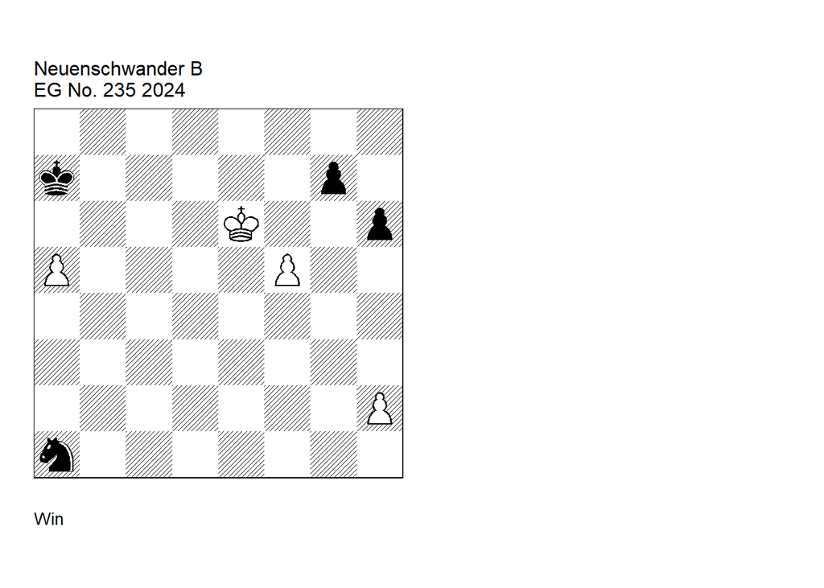

GBR: +0003.32e6a7 FEN: 8/k5p1/4K2p/P4P2/8/8/7P/n7 w - - 0 1

**1. Kf7 h5 2. h4! Patience!** (2. Kxg7? h4!! (2… Nb3? 3. h4! =main line ) 3. f6 Nb3 4. f7 Nc5 5. f8=Q Ne6+ 6. Kf7 Nxf8 7. Kxf8 =) **2… Nb3 3. Kxg7 Nxa5 4. f6 Nb7** (4… Nc6 5. f7 Nd8 6. Kf6! wins a decisive tempo (6. f8=Q? Ne6+ 7. Kf7 Nxf8 8. Kxf8 Kb7 =) 6… Nxf7 7. Kxf7 Kb7 8. Kg6 Kc7 9. Kxh5 Kd7 10. Kg6 Ke7 11. Kg7 +/-) **5. Kf7!! Patience!** (5. f7? Nc5! = ( 5… Nd8? 6. Kf6! +/- see 4…Nc6 ) ) **5… Nd8+** (5… Nd6+ 6. Ke6 +/- (6. Ke7? Nf5+ =) ) **6. Ke8** (6. Ke7? Nc6+ =) **6… Ne6 7. f7** (7. Ke7? Nf4 =) **7… Kb7 8. Ke7 1-0**.

# Comments and revisions

## Studies by Zakhodyakin

Zakhodyakin in HHdbVI

| no | res.gbr.Kk | comments | year | source |
| --- | --- | --- | --- | --- |
| 1 | =0010.22h4h6 | U3” | 1929 | 4.hm 64#413 |
| 2 | =0040.11h2e2 |  | 1929 | 64#403 |
| 3 | +0030.22e3h2 |  | 1929 | Izvestia#260 |
| 4 | +0030.32a6e6 |  | 1929 | 64#387 |
| 5 | +0031.22b8a6 | U1” | 1930 | Shakhmatny Listok#490 |
| 6 | +3012.13a2c4 |  | 1930 | 5.p 64#500 |
| 7 | +0161.00e1a8 |  | 1930 | 64#485 |
| 8 | +0161.00e1a8 | (v)” | 1930 | 64#485 |
| 9 | =0014.22a2h8 |  | 1930 | 1.p Shakhmatny Listok#474 |
| 10 | +4001.02h6g8 |  | 1930 | .c Shakhmatny Listok#472 |
| 11 | +0018.01h7f8 | U3” | 1930 | 64#472 |
| 12 | +0018.02h7f8 | (c) U2 U3” | 1930 | 64#472 |
| 13 | +3114.00h6g8 | (c)” | 1930 | 64#472 |
| 14 | +0133.10e7g7 |  | 1930 | .c 64#451 |
| 15 | +0042.01c6f4 |  | 1930 | 64#437 |
| 16 | =4016.21a1c1 | U3” | 1931 | 4.p 64#571 |
| 17 | =0310.22f6c6 | U3” | 1931 | 64#570 |
| 18 | +0106.20e3h8 |  | 1931 | 2.hm 64#558 |
| 19 | +0027.01c3e6 | U1 U2” | 1931 | 2.p 64#550 |
| 20 | +0054.01b4e5 | U3” | 1931 | 64#551 |
| 21 | +0054.02a4e5 | (c)” | 1931 | 64#551 |
| 22 | +0054.02b4e5 | (c)” | 1931 | 64#551 |
| 23 | +0013.10d4h8 |  | 1931 | 1.p 64#543 |
| 24 | +0050.11b2a6 |  | 1931 | 64#521 |
| 25 | =0074.10e5g6 | U3” | 1931 | .c 64#518 |
| 26 | +0302.10g4a5 |  | 1931 | 64#517 |
| 27 | +0302.10g4a5 | (m)” | 1931 | 64#517 |
| 28 | +0302.10h4b5 | (m) U2” | 1931 | 64#517 |
| 29 | +0111.04a7a1 | (c)” | 1931 | 3.p Shakhmatny Listok#504 |
| 30 | +0111.04a7a1 | (c)” | 1931 | 3.p Shakhmatny Listok#504 |

[output cut: 218 more lines]

### Zakhodyakin +4001.02h6g8 (1930). Cook/correction/modification

Date: 2024, March 22

File: Zakhodyakin1930a.pgn

**Study no. 10** (Table 1)

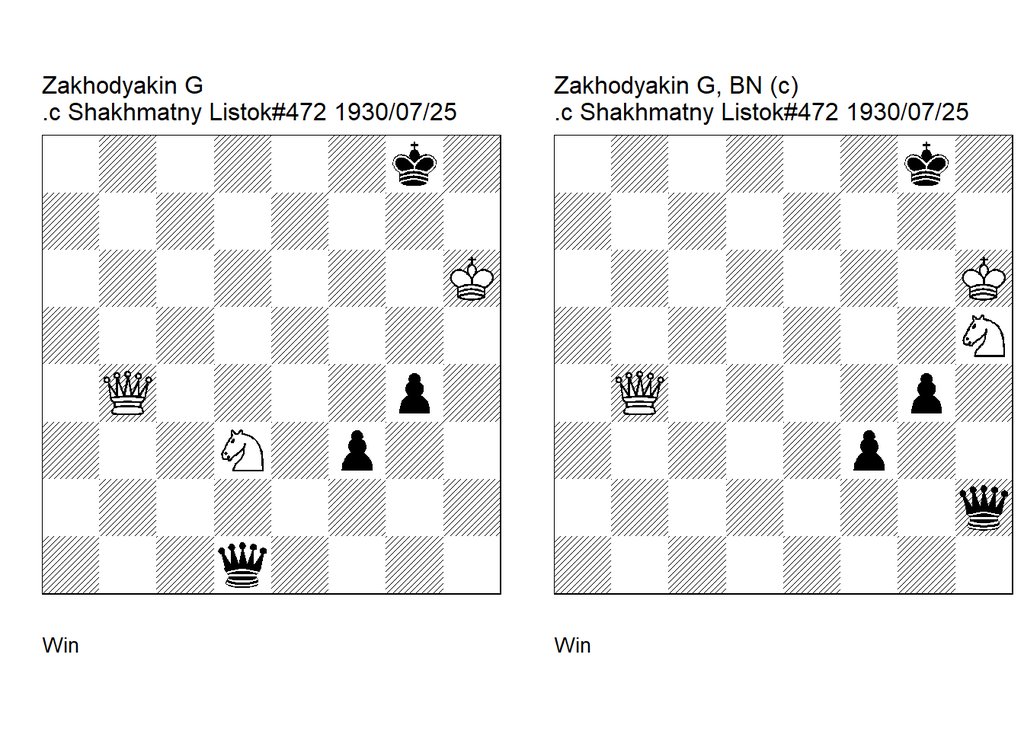

GBR: +4001.02h6g8 FEN: 6k1/8/7K/8/1Q4p1/3N1p2/8/3q4 w - - 0 1

**Shakhmatny Listok=14. U1: Neuenschwander=B beatochess 22/03/2024 . 1. Qe7** (1. Qc4+! cook BN 1… Kf8 2. Kg6 Ke8 3. Qc8+ Ke7 4. Qc7+ Ke8 (4… Ke6 5. Nf4 ) 5. Kf6 Qa1+ 6. Ne5 Qa6+ 7. Kg7 and Stockfish-16 gives a mate in 17 ) **1… Qd2+ 2. Nf4! Qh2+!** (2… Qxf4+ 3. Kg6) **3. Nh3!** (3. Kg6? Qc2+) **3… Qd2+** (3… Qxh3+ 4. Kg6) **4. Ng5 Qh2+ eg 5. Kg6 Qc2+ 6. Ne4 Qc6+ 7. Nf6+ 1-0**.

GBR: +4001.02h6g8 FEN: 6k1/8/7K/7N/1Q4p1/5p2/7q/8 w - - 0 1

**correction: Neuenschwander=B beatochess 22/03/2024. 1. Qe7 Qd2+ 2. Nf4!** (2. Kg6? Qc2+ 3. Kh6 Qc1+ =) **2… Qh2+ 3. Nh3!** (3. Kg6? Qc2+ 4. Kf6 Qc6+ 5. Ne6 Qc3+ =) **3… Qd2+ 4. Ng5** (4. Kg6? Qc2+ =) **4… Qh2+ 5. Kg6 Qc2+ 6. Ne4 1-0**.

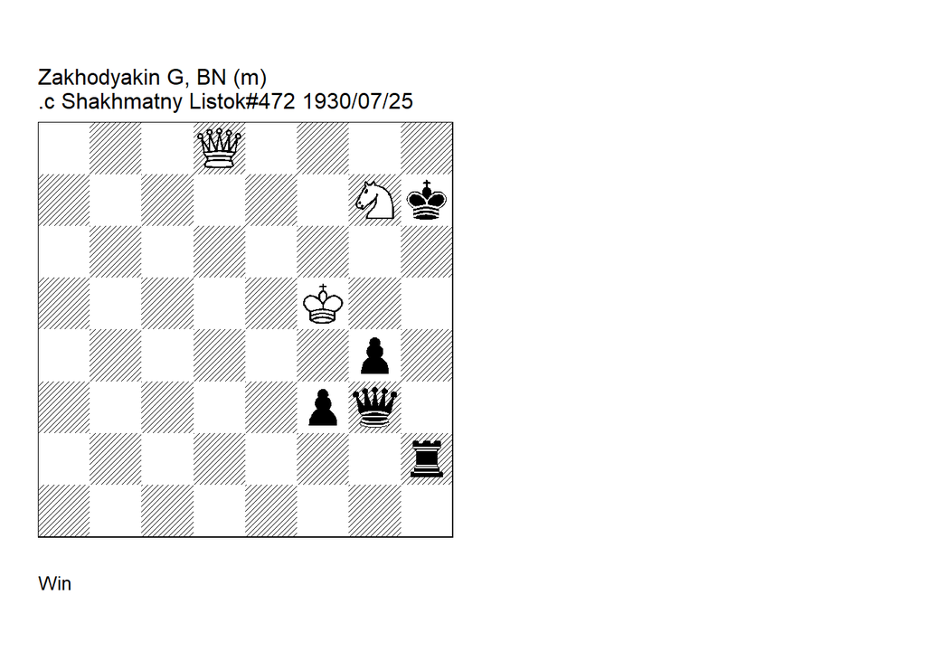

GBR: +4301.02f5h7 FEN: 3Q4/6Nk/8/5K2/6p1/5pq1/7r/8 w - - 0 1

**modification: Neuenschwander=B beatochess 22/03/2024. 1. Qe7 Kg8** (1… Qh4 2. Qf7 Kh8 (2… Qh6 3. Nh5+ Kh8 4. Qe8+ Kh7 5. Qe7+ Kh8 6. Qe5+ Kg8 7. Nf6+ +/-) 3. Qf8+ Kh7 4. Ne6 Qh5+ 5. Ng5+ (theme) 5… Qxg5+ 6. Kxg5 +-) **2. Kg6 Rh6+** ( 2… Qb8 3. Nf5 (theme) 3… Qb6+ 4. Nd6 Qb1+ 5. Ne4 (theme) 5… Qb6+ 6. Nf6+ (theme) ) **3. Kxh6 Qh2+ 4. Nh5** (theme) **4… Qd2+ 5. Nf4** (theme) **5… Qh2+ 6. Nh3** (theme) **6… Qd2+ 7. Ng5** (theme) **7… Qh2+ 8. Kg6 Qc2+ 9. Ne4** (theme) **1-0**.

### Zakhodyakin +0018.01h7f8 (1930). Modification

Date: 2024, March 23

File: Zakhodyakin1930b.pgn

**Study nos. 11, 12** (Table 1)

Mario Garcia’s attempt to correct the study failed, but Peter Krug succeeded. My version is another correction, a bit more in the light-material spirit of Zakhodyakin’s original.

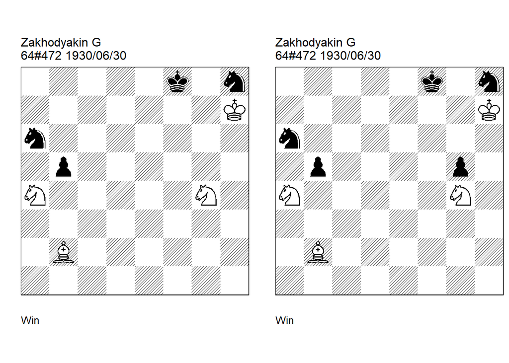

GBR: +0018.01h7f8 FEN: 5k1n/7K/n7/1p6/N5N1/8/1B6/8 w - - 0 1

**64=17-18 . U3: Beasley=J HHdbIII 54385 3-2-2002. 1. Nc5 Nxc5 2. Ba3 Ke8** (2… Kf7! cook JB 3. Bxc5 Ng6 4. Nh6+ Kf6 5. Bd4+ Kg5 6. Nf7+ Kh5) (2… b4! cook JB 3. Bxb4 Kf7) **3. Bxc5 Nf7 4. Kg6 Nd8 5. Nf6 1-0**.

GBR: +0018.02h7f8 FEN: 5k1n/7K/n7/1p4p1/N5N1/8/1B6/8 w - - 0 1

**64=17-18 . correction: Garcia=M Estudios Artisticos de Ajedrez - XI-98 2012. U2 U3: Van, der, Heijden=H HHdbV 70675 1-2-2014. 1. Nc5 Nxc5 2. Ba3 Ke8** (2… Kf7 3. Bxc5 Ng6 4. Nh6+ Kf6 5. Bd4+ Ne5 6. Ng4+ Kf5! cook HH 7. Nxe5 g4 8. Kh6 g3 9. Kh5 Ke4) (2… b4 3. Bxb4 Kf7 4. Bxc5 Ng6 5. Nh6+ Kf6 6. Bd4+ Ne5 7. Ng4+ Kf5 8. Nxe5) **3. Bxc5 Nf7 4. Kg6** (4. Kg7! cook HH ) (4. Kg8! cook HH ) **4… Nd8 5. Nf6 1-0**.

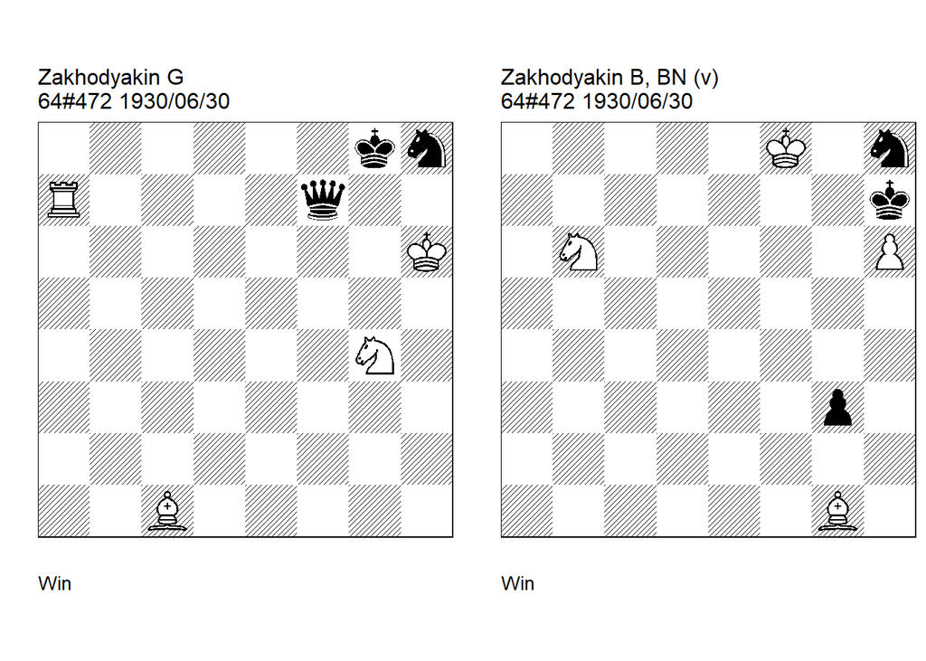

GBR: +3114.00h6g8 FEN: 6kn/R4q2/7K/8/6N1/8/8/2B5 w - - 0 1

**64=17-18 . correction: Krug=P Estudios Artisticos de Ajedrez - XX-5 2017. 1. Ra8+!** (1. Rxf7? Kxf7! (1… Nxf7+? 2. Kg6 Kf8 3. Ba3+) ) **1… Qf8+ 2. Rxf8+ Kxf8 3. Kh7 Nf7 4. Ba3+ Ke8 5. Kg6 Nd8** (5… Nh8+ 6. Kg7 Nf7 7. Nf6+ Kd8 8. Kxf7) **6. Nf6 1-0**.

GBR: +0014.11f8h7 FEN: 5K1n/7k/1N5P/8/8/6p1/8/6B1 w - - 0 1

**version: Neuenschwander=B beatochess 23/03/2024 1. Nd7!** (1. Be3? Ng6+ 2. Kf7 Ne5+ 3. Ke6 Nf3 =) (1. Nd5? Kxh6 =) **1… Kxh6** (1… Ng6+ 2. Kf7 Nh4 3. Nf6+ Kxh6 4. Be3 ) **2. Kg8 Ng6 3. Be3+ Kh5 4. Kf7 Nh4** (4… g2 5. Nf6+ Kh4 6. Kxg6) **5. Nf6 1-0**.

### Zakhodyakin +0161.00e1a8 (1930). Comment

Date: 2024, March 23

File: Zakhodyakin1930c.pgn

**Study no. 7** (Table 1)

The reason for the second study (author’s correction) is the cook **1.Ne6**. This information is missing in **HHdbVI**.

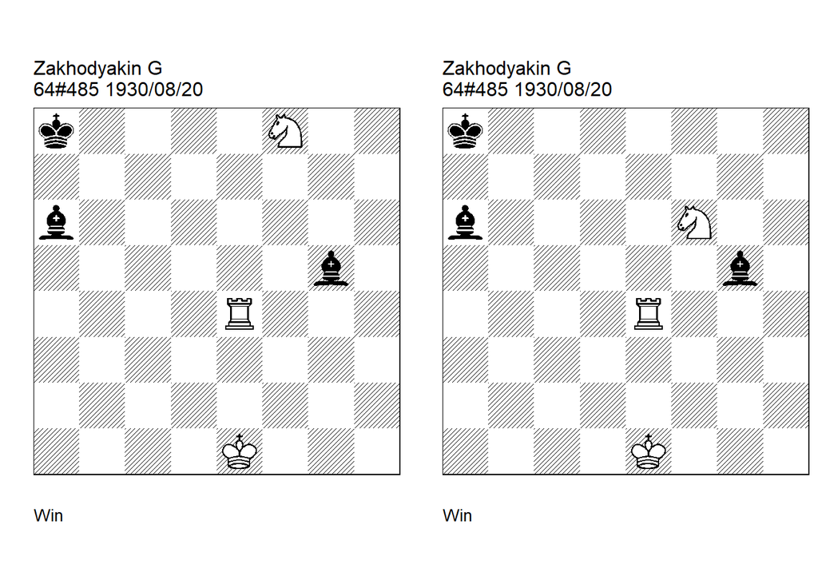

GBR: +0161.00e1a8 FEN: k4N2/8/b7/6b1/4R3/8/8/4K3 w - - 0 1

**64=22-23. U1: Neuenschwander=B beatochess 23/03/2024 . 1. Nh7** (1. Ne6! cook BN 1… Bf6 2. Ra4) **1… Bc1! 2. Kd1 Bb2** (2… Bd3 main 3. Re8+ Kb7 4. Kxc1 Bxh7 5. Re7+ Kc6 6. Rxh7) **3. Kc2 Ba1** (3… Bg7 4. Re8+ Ka7 5. Re7+) (3… Ba3 4. Ra4) **4. Ra4 1-0**.

GBR: +0161.00e1a8 FEN: k7/8/b4N2/6b1/4R3/8/8/4K3 w - - 0 1

**64=22-23 . 1. Nh7 Bc1 2. Kd1 Bb2** (2… Bd3 main 3. Re8+ Kb7 4. Kxc1 Bxh7 5. Re7+ Kc6 6. Rxh7) **3. Kc2 Ba1** (3… Ba3 4. Ra4) (3… Bg7 4. Re8+ Kb7 5. Re7+ Kc6 6. Rxg7) **4. Ra4 1-0**.

### Zakhodyakin +0031.22b8a6 (1930). Correcction, modifications

Date: 2024, March 24

File: Zakhodyakin1930d.pgn

**Study no. 5** (Table 1)

In addition to Mario Garcia’s cook **1.Nd4**, the queen promotion **6.b8=Q** at the end also wins. The second study is a same-material correction. Studies 3 and 4 are modifications.

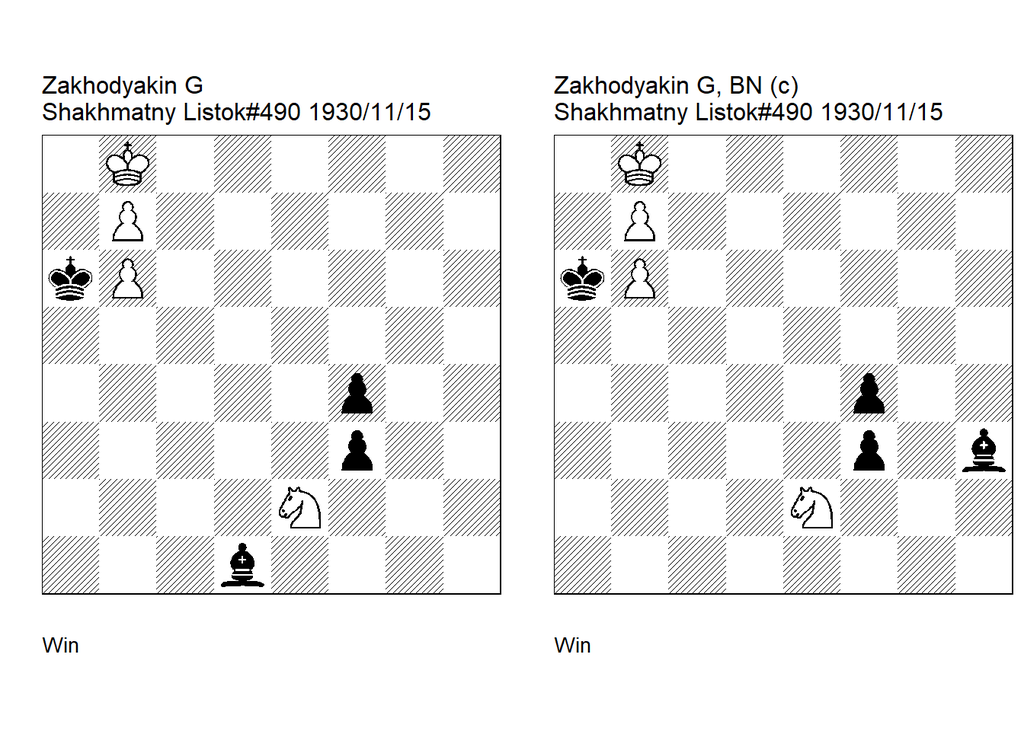

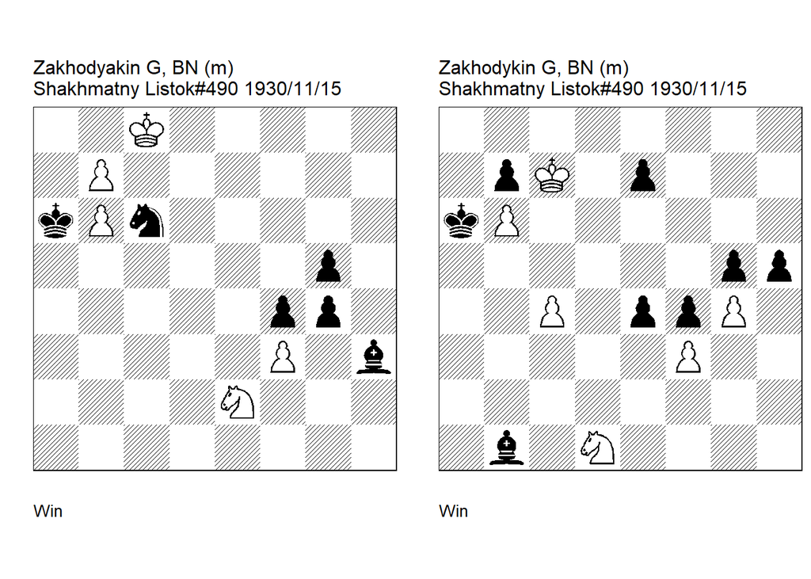

GBR: +0031.22b8a6 FEN: 1K6/1P6/kP6/8/5p2/5p2/4N3/3b4 w - - 0 1

GBR: +0031.22b8a6 FEN: 1K6/1P6/kP6/8/5p2/5p1b/4N3/8 w - - 0 1

**correction: Neuenschwander=B beatochess 24/03/2024. 1. Nc3 f2 2. Kc7 f1=Q 3. b8=N+** (3. b8=Q? Qc4+ 4. Kd6 Qxc3) **3… Ka5 4. Nc6+ Ka6 5. b7 Qd3 6. b8=N** (6. Nd5? Qh7+ 7. Nde7 Qb1) (6. b8=Q? Qd7 ) **1-0**.

GBR: +0034.33c8a6 FEN: 2K5/1P6/kPn5/6p1/5pp1/5P1b/4N3/8 w - - 0 1

**modfication: Neuenschwander=B beatochess 24/03/2024. 1. Kc7 Nb8** (1… Bg2 2. Nd4 Nxd4 3. b8=Q +-) (1… gxf3 2. Kxc6 Bd7+ 3. Kc7 fxe2 4. b8=Q e1=Q 5. Qa8+ Kb5 6. Qd5+ Ka6 7. Qa2+ Kb5 8. Qb2+ Kc5 9. b7 +-) **2. Kxb8** (2. Nd4 gxf3 3. Nxf3 Bg2) (2. Nxf4 gxf3 3. Nxh3 g4 4. Kxb8 gxh3 =) **2… gxf3 3. Nc3** (3. Nd4? f2 4. Kc7 f1=Q 5. b8=Q Qc4+ 6. Nc6 Qf7+ 7. Kd6 Qe6+ 8. Kc5 Qe3+ =) **3… f2 4. Kc7 f1=Q 5. b8=N+ Ka5 6. Nc6+ Ka6 7. b7 Qd3 8. b8=N** (8. Nd5 Qh7+ 9. Nde7 Qb1 =) **1-0**.

GBR: +0031.46c7a6 FEN: 8/1pK1p3/kP6/6pp/2P1ppP1/5P2/8/1b1N4 w - - 0 1

**modification: Neuenschwander=B beatochess 24/03/2024. 1. c5** (1. gxh5? e3) **1… e3 2. Nc3 e2 3. Nxe2 hxg4 4. c6 gxf3 5. Nc3 f2 6. cxb7 f1=Q 7. b8=N+! Ka5 8. Nc6+ Ka6 9. b7 Qd3 10. b8=N ! 1-0**.

### Zakhodyakin =0310.22f6c6 (1931). Correction

Date: 2024, March 26

File: Zakhodyakin1931a.pgn

**Study no. 17** (Table 1)

Both **1…Rc8** and **1…Ra8** cook the study. I managed to save the study with two additional pawns. In the correction, White’s play after 1… Rc8 requires precision.

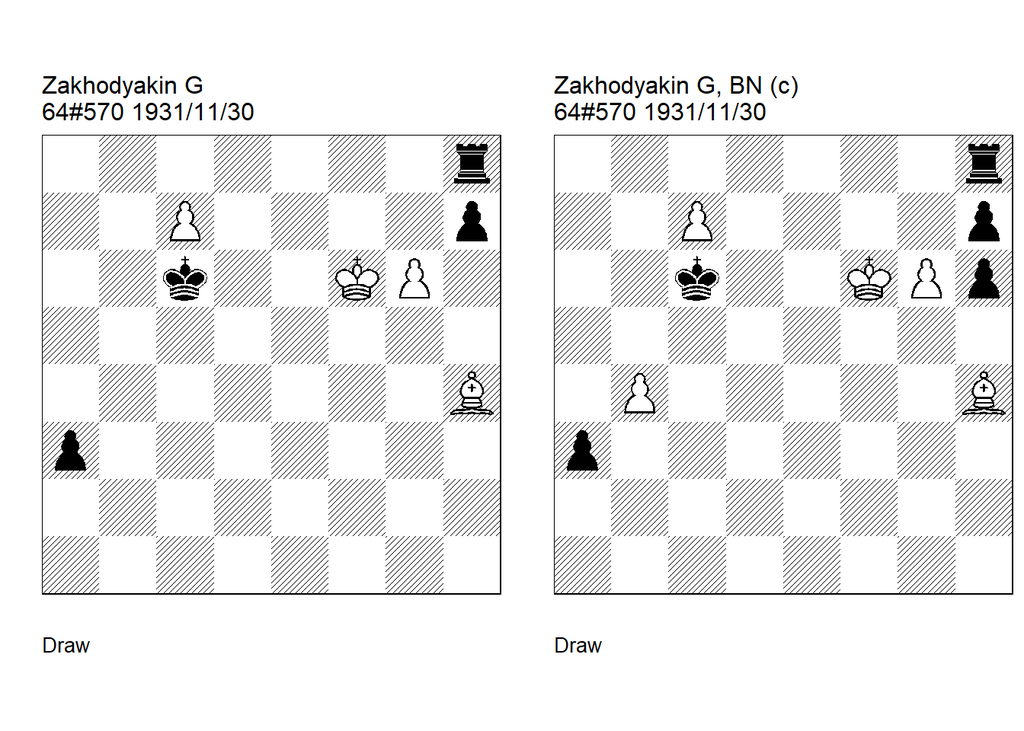

GBR: =0310.22f6c6 FEN: 7r/2P4p/2k2KP1/8/7B/p7/8/8 w - - 0 1

**64=21-22 . U3: 64=12 10-1-1933 U3: Neuenschwander=B beatochess 26/03/2024. 1. g7 a2** (1… Rc8! cook 2. Bg3 a2 3. Be5 h5) (1… Ra8! cook BN 2. Bg3 a2 3. Be5 h5) **2. gxh8=Q a1=Q+ 3. Kf7 Qxh8 4. Bd8! Kd7 5. c8=Q+! Kxc8 6. Bf6! Qd8 7. Bxd8 Kxd8 8. Kf6 1/2-1/2**.

GBR: =0310.33f6c6 FEN: 7r/2P4p/2k2KPp/8/1P5B/p7/8/8 w - - 0 1

**correction: Neuenschwander=B beatochess 26/03/2024. 1. g7 a2** (1… Rc8 2. Bg3 a2 (2… h5 3. Kg5 a2 4. Be5 Re8 5. Kh4 Kb7 6. Kg3) 3. Be5 Kb7 4. Kf5 Re8 5. Kf4! (5. b5? Rxe5+) (5. Kg4? Kc6 6. Kf4 h5 7. Kg3 Kd5) 5… h5 6. Kg3 Kb6 (6… Kc6 7. Kh4) 7. Kh3 Kc6 (7… Kb5 8. Kg3 Kxb4 9. Kh4 Kc5 10. Ba1 Kc6 11. Kxh5) 8. Kh4 Kb7 (8… Kd7 9. b5) 9. Kg3) **2. gxh8=Q a1=Q+ 3. Kf7 Qxh8 4. Bd8 Kd7 5. c8=Q+ Kxc8 6. Bf6 1/2-1/2**.

### Zakhodyakin +0161.00b3a8 (1933). Version

Date: 2024, March 27

File: Zakhodyakin1933.pgn

**Study no. 47** (Table 1)

In the original study, **5.Nc5** also wins; strictly speaking a cook, although not really an important one. My version shows the domination slightly differently: both bishops are on the fourth rank after 1… Bb4 (variation) and at the end of the study.

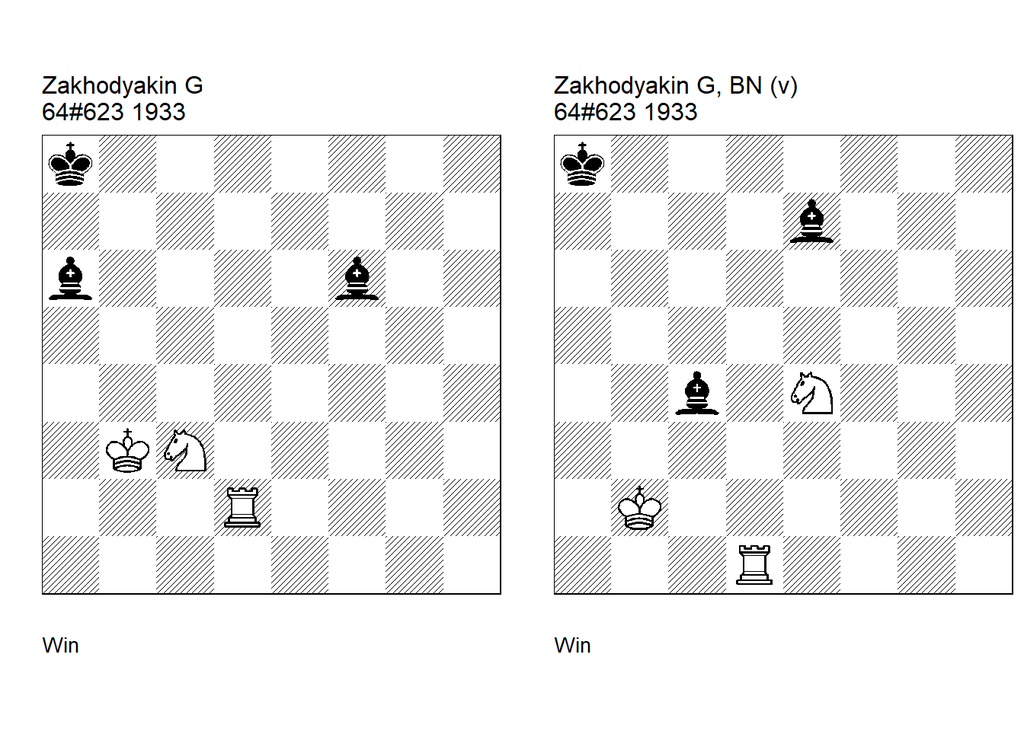

GBR: +0161.00b3a8 FEN: k7/8/b4b2/8/8/1KN5/3R4/8 w - - 0 1

**64=1 64/1. U2: Neuenschwander=B beatochess 27/03/2024. 1. Ne4!** (1. Rd6? Bxc3) **1… Be7!** (1… Be5 2. Ra2 Ka7 3. Nc5) **2. Rd7 Bh4 3. Rh7 Be1 4. Rh1 Ba5 5. Ra1** (5. Nc5 cook BN ) **1-0**.

GBR: +0161.00b2a8 FEN: k7/4b3/8/8/2b1N3/8/1K6/3R4 w - - 0 1

**version: Neuenschwander=B beatochess 27/03/2024. 1. Rd7 Bh4** (1… Bb4 2. Rd4) **2. Rh7 Be1 3. Rh1 Bb4** (3… Ba5 4. Ra1 (4. Nc5 or ) ) **4. Ra1+ Kb7 5. Ra4 1-0**.

## Shakhmatny Listok studies

### Gorgiev +0170.02e5d7 (1929). Correction

Date: 2024, February 28

File: Gorgiev1929.pgn

With an additional black pawn on g3, Gorgiev’s study is correct.

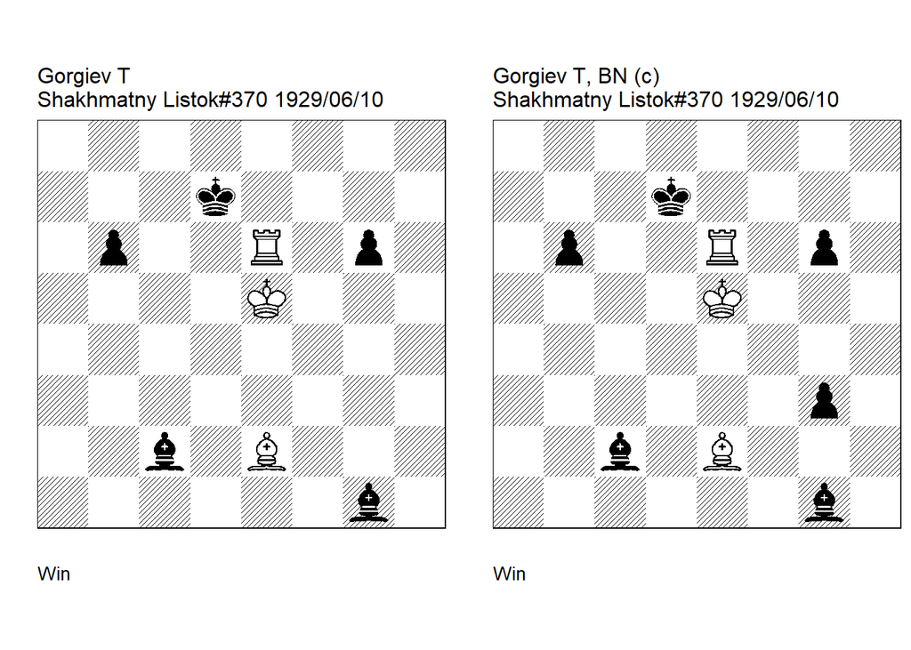

GBR: +0170.02e5d7 FEN: 8/3k4/1p2R1p1/4K3/8/8/2b1B3/6b1 w - - 0 1

**Shakhmatny Listok=11. U2: Neuenschwander=B beatohess 28/02/2024 . 1. Bb5+ Kd8! 2. Rd6+ Ke7 3. Rd7+ Kf8! 4. Kf6 Kg8! 5. Bc4+ Kh8! 6. Rd8+!** ( White has a big advantage due to the bad position of the black king:) (6. Rd2! cook BN 6… Be4 7. Re2) (6. Be6! cook BN e.g. 6… Be3 7. Ra7 Bd4+ 8. Kf7 Kh7 9. Ra2) **6… Kh7 7. Bg8+ Kh6! 8. Bb3!** (8. Be6? g5) **8… Bd4+** ( 8… Bxb3 main 9. Rh8 ) **9. Rxd4 Bxb3 10. Rh4 1-0**.

GBR: +0170.03e5d7 FEN: 8/3k4/1p2R1p1/4K3/8/6p1/2b1B3/6b1 w - - 0 1

**correction: Neuenschwander=B beatochess 28/02/2024. 1. Bb5+ Kd8 2. Rd6+ Ke7 3. Rd7+ Kf8 4. Kf6 Kg8 5. Bc4+ Kh8 6. Rd8+ Kh7 7. Bg8+ Kh6 8. Bb3 Bxb3** (8… Bd4+ 9. Rxd4 Bxb3 10. Rh4 ) **9. Rh8 1-0**.

### Prokop =4160.22e5a2 (1929). Cook, correction

Date: 2024, March 1

File: Prokop1929.pgn

In Peter Krug’s correction, the line **1. Rxh2 … 3. Qa5+** seems to lead to a drawn endgame according to tablebase information.

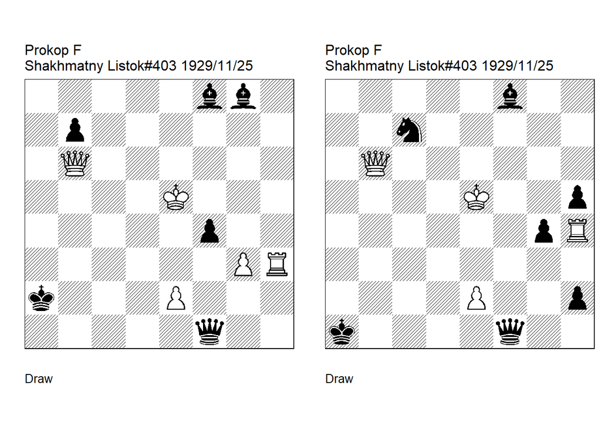

GBR: =4160.22e5a2 FEN: 5bb1/1p6/1Q6/4K3/5p2/6PR/k3P3/5q2 w - - 0 1

**Shakhmatny Listok=22 . U3: Weger=Z EBUR=1 3/1996. 1. Rh2!** (1. Qa5+? Ba3!) (1. Rh4? fxg3 2. Ra4+ Ba3 3. Qe3 Bb3) **1… fxg3!** (1… Bg7+ main 2. Ke4 fxg3 3. e3+! gxh2 (3… g2! cook ZW 4. Qa5+ Kb1 5. Qb6+ Ka1) 4. Qb2+! Kxb2 (4… Bxb2) ) **2. e4+! gxh2 3. Qf2+! Qxf2 1/2-1/2**.

GBR: =4133.13e5a1 FEN: 5b2/2n5/1Q6/4K2p/6pR/8/4P2p/k4q2 w - - 0 1

**Shakhmatny Listok=22 . correction: Krug=P Estudios Artisticos de Ajedrez - XVI-6 2015. U1: Neuenschwander=B 01/03/2024. 1. Qd4+!** (1. Rxh2? Bg7+ 2. Ke4 g3 3. e3 (3. Qa5+! cook BN 3… Kb1 4. Qxc7 gxh2 5. Qxh2 = (tablebase ) 3… Qc4+!) 1… Kb1 (1… Ka2 2. Qc4+ Kb2 (2… Ka3 3. Qc3+ Ka4 4. Qc4+ Bb4 5. Rxh2) 3. Rxh2 Qg1 4. Rxh5) 2. Qb6+! (2. Qd3+? Kb2 3. Rxh2 Qg1! 4. Rxh5 Qc5+ 5. Kf4 Qxh5) 2… Ka2 3. Rxh2 g3 (3… Bg7+ main 4. Ke4 g3 5. e3+ gxh2 6. Qb2+ (6. Qb3+ or ) (6. Qa5+ or ) 6… Kxb2 ( 6… Bxb2) ) 4. e4+ gxh2 5. Qf2+ Qxf2 1/2-1/2**.

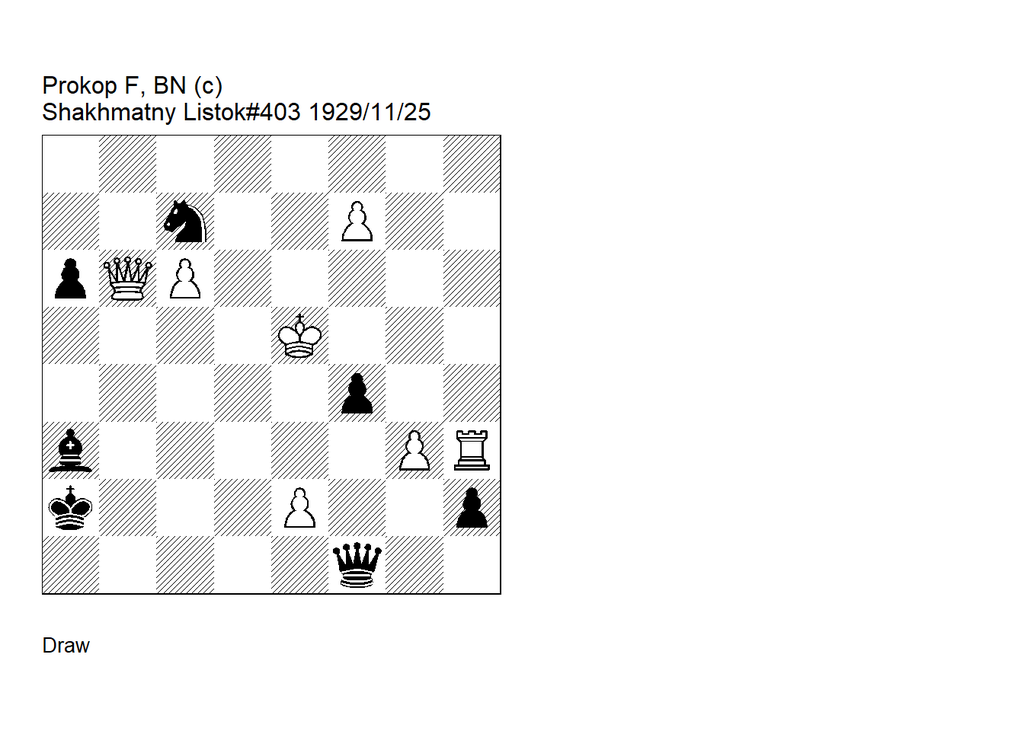

GBR: =4133.43e5a2 FEN: 8/2n2P2/pQP5/4K3/5p2/b5PR/k3P2p/5q2 w - - 0 1

**correction: Neuenschwander=B beatochess 01/03/2024. 1. f8=Q** (1. Rxh2 fxg3 -/+) **1… Bxf8** (1… Qxe2+ 2. Kf5 Qe6+ (2… Bxf8 3. Qxc7) 3. Kg5 Be7+ 4. Kxf4 Nd5+ 5. Kf3 Nxb6 6. Rxh2+) **2. Rxh2 fxg3** (2… Bg7+ main 3. Ke4 fxg3 4. e3+ gxh2 5. Qb2+ (5. Qa5+ or ) (5. Qb3+ or ) ) **3. e4+ gxh2 4. Qf2+ Qxf2 1/2-1/2**.

Date: 2024, March 3

File: Havasi1929.pgn

**1. g6** is a (serious?) dual, because after 1… Ne6, White plays **2. b4!** (instead of 2.f5), which transposes into the main line.

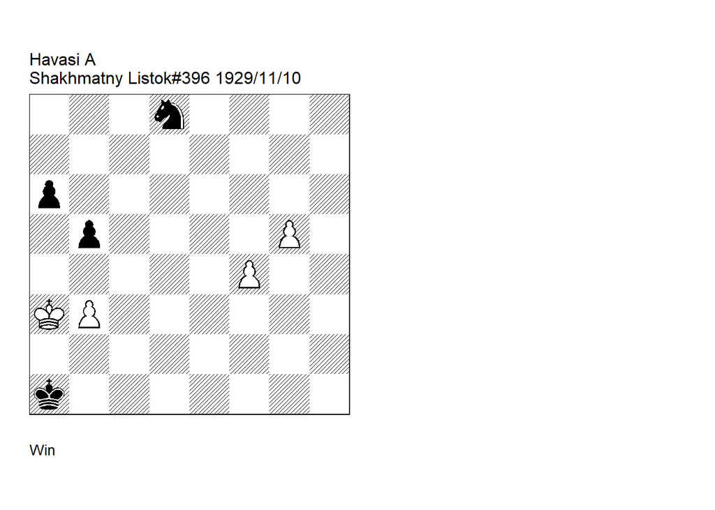

GBR: +0003.32a3a1 FEN: 3n4/8/p7/1p4P1/5P2/KP6/8/k7 w - - 0 1

**Shakhmatny Listok=21. U1: Neuenschwander=B beatochess 03/03/2024 . 1. b4!** ( 1. f5? a5! 2. f6 Nc6 3. f7 Nd4 4. f8=Q Nc2 ) (1. g6? Ne6 2. f5 (2. b4! cook BN leads to the main variation ) 2… Nd4) (1. Kb4? Ne6 2. g6 Nxf4 3. g7 Nd5+ 4. Ka5 Ne7! 5. Kxa6 Kb2 6. b4 Kc3 7. Kxb5 Kd4 8. Kb6 Ke5 9. Kc7 Kf6 10. Kd7 Kf7) **1… Ne6 2. g6 Ng7 3. Kb3 Ne6 4. Kc2 1-0**.

### Bron +0400.52h6a5 (1929). Not cooked?

Date: 2024, March 5

File: Bron1929.pgn

It seems that the claimed cook **1. b7** is dangerous but not sufficient for a win.

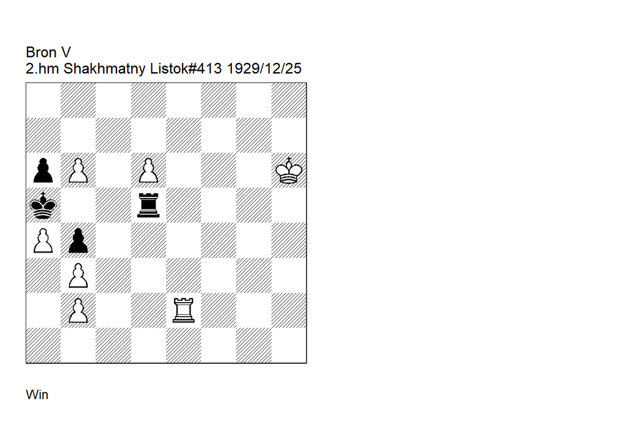

GBR: +0400.52h6a5 FEN: 8/8/pP1P3K/k2r4/Pp6/1P6/1P2R3/8 w - - 0 1

**Shakhmatny Listok=24 . U1: De, Zeeuw=M HHdbIV 12923 1-9-2005. Neuenschwander=B beatochess 05/03/2024: the claim seems incorrect according to Stockfish-16. 1. Re5!** (1. b7! cook MZ 1… Rxd6+ 2. Kg5! Rd8 (2… Rd5+ 3. Kf6 Rd8 4. Ke7 Rb8 5. Kd6 Kb6 (5… Rxb7 6. Re5+ Kb6 7. a5+ Ka7 8. Re7) 6. Re7 Ka5 7. Kc6 Rc8+ 8. Kd5 Rb8 9. Kd6 Rxb7 10. Re5+) 3. Kf6 Rb8 (3… Kb6 4. Re7 Rb8 (4… Ka7! BN seems equal ) 5. Ke5 Rxb7 6. Rxb7+ Kxb7 7. Kd5) 4. Re5+ Kb6 5. Re7 Ka5 (5… Ka7 6. Ke6 Kb6 7. Kd5 Ka5 8. Kc6) 6. Ke5 Rxb7 (6… Rd8 7. Rc7 Rb8 8. Kd6 Rxb7 9. Rc5+ Kb6 10. a5+ Ka7 11. Rc7) 7. Kd6 Rb8 (7… Rb6+ 8. Kd5 Rc6 9. Re5 (9. Kxc6?) 9… Rc2 10. Kd6+ Kb6 11. a5+ Ka7 12. Re7+ Ka8 13. Kd5 Rxb2 14. Kc4 Rh2 15. Kxb4) 8. Re5+ Kb6 9. a5+ Ka7 (9… Kb7 10. Re7+ Ka8 11. Kc6) 10. Kc5 Rb5+ 11. Kd4) (1. Re6? Rxd6 2. Rxd6) **1… Rxe5 2. d7 Re6+!** (2… Rf5 3. d8=Q Rf6+ 4. Kh5 Rf5+ (4… Rh6+ 5. Kg4 Rg6+ 6. Qg5+) 5. Qg5) (2… Rd5 3. b7) **3. Kg5! Rxb6! 4. d8=N!** (4. d8=Q?) **4… Rb8** (4… Rd6 main 5. Nb7+ Kb6 6. Nxd6) **5. Nc6+ Kb6 6. Nxb8 1-0**.

### Selezniev +0301.34a4d4 (1930). Cook/correction

Date: 2024, March 15

File: Selezniev1930.pgn

Unfortunately, the promotion to a rook **4. c8=R!** gives White an overwhelming advantage, although **4. c8=B!** wins much more easily of course. The correction adds the Excelsior theme to the study.

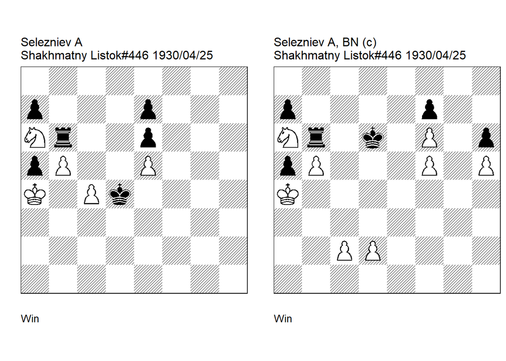

GBR: +0301.34a4d4 FEN: 8/p3p3/Nr2p3/pP2P3/K1Pk4/8/8/8 w - - 0 1

**Shakhmatny Listok=8. U2: Neuenschwander=B beatochess 15/03/2024 . 1. c5 Rxa6! 2. c6 Kc5! 3. c7 Kb6! 4. c8=B** (4. c8=Q?) (4. c8=R! cook BN 4… Kb7 5. Rh8 gives White a big advantage, e.g. 5… Rb6 6. Re8 a6 7. Rxe7+ Kb8 8. bxa6 Rxa6 9. Kb5 Ra7 10. Rxa7 Kxa7 11. Kxa5) (4. c8=N+? Kb7) **1-0**.

GBR: +0301.64a4d6 FEN: 8/p4p2/Nr1k1P1p/pP3P1P/K7/8/2PP4/8 w - - 0 1

**correction: Neuenschwander=B beatochess 15/03/2024. 1. c4** (1. Kxa5? Kd5) **1… Ke5** (1… Kd7 2. Nc5+! Kd6 (2… Kd8 3. Ne4 +-) 3. d4 +-) **2. d4+!** ( 2. c5? Rxf6 3. d4+ Kd5! 4. Kxa5 Rxf5 5. c6 Kd6 =) (2. Kxa5? Rd6 3. c5 Rxd2 4. Nb4 Rd1! 5. Ka6 Rb1! 6. c6 Kd6 7. Nd5 Rc1 8. Kb7 a6! 9. bxa6 (9. b6 Rxc6 =) 9… Rb1+ 10. Nb6 Kc5 11. c7 Rxb6+ 12. Ka7 Rc6 13. Kb7 Rb6+ 14. Kc8 Rxa6 15. Kd8 Rd6+ 16. Ke7 Rc6 =) **2… Kxd4** (2… Kxf6 3. c5 Rb7 4. c6 Re7 5. Kxa5 +-) **3. c5 Rxa6 4. c6 Kc5 5. c7 Kb6 6. c8=B! 1-0**.

### Lapin/Garcia +0113.13c3e2 (1930). Cook?

Date: 2024, March 16

File: Lapin1930.pgn

The correction by Garcia is not convincing. It seems that **2. Bc4+ Kg1 3. Rh5!** (instead of 3.Rxh7) leads to an alternative win, although the lines are a bit murky.

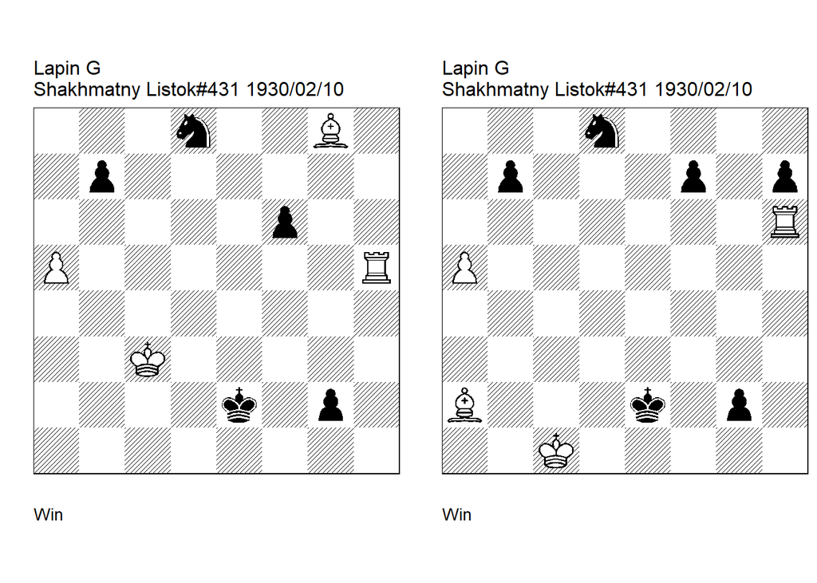

GBR: +0113.13c3e2 FEN: 3n2B1/1p6/5p2/P6R/8/2K5/4k1p1/8 w - - 0 1

**Shakhmatny Listok=3 . U2: Shakhmatny Listok=15-16 10-8-1930** (U2) **: Haworth=G Bleicher=E HHdbV 71040 9-12-2009. 1. Rh2 Kf1 2. Kd2** (2. Bc4+! cook Kg1 3. Rh6 Kf2 4. Rxf6+ Ke3 5. Rg6 Kf2 6. Kb4 g1=Q 7. Rxg1 Kxg1 8. Bd5 Kf2 9. Bxb7 Nxb7 10. a6 Nd8 11. Kb5 Ne6 12. Kb6) **2… Kg1 3. Rh3! Kf2 4. Bd5! g1=Q 5. Rf3+ Kg2 6. Rxf6+ Kh3 7. Rh6+ Kg3 8. Rg6+ Kf2 9. Rxg1 Kxg1 10. Bxb7** (10. Ke3! minor, dual GH/EB) **10… Nxb7 11. a6 1-0**.

GBR: +0113.14c1e2 FEN: 3n4/1p3p1p/7R/P7/8/8/B3k1p1/2K5 w - - 0 1

**Shakhmatny Listok=3 . correction: Lapin=G 64 590 64=5 5/1932. U2: Garcia=M Estudios Artisticos de Ajedrez - VI-44 2012. 1. Rh2 Kf1 2. Kd2** (2. Bc4+! cook MG 2… Kg1 3. Rxh7 Kf2 4. Rh2 Kg3 5. Rxg2+ Kxg2 6. Bd5+ Kf2 7. Bxb7 Ne6 8. Kc2 Ke3 9. Kc3 Nc7 10. Kc4 Kd2 11. Kc5 Kc3 12. Kb6 Kb4 13. Bc6 f5 14. Bf3) **2… Kg1! 3. Rh3! Kf2 4. Bd5 g1=Q 5. Rf3+ Kg2 6. Rxf7+ Kg3 7. Rg7+ Kf2 8. Rxg1 Kxg1 9. Ke2 h5 10. Bxb7 Ne6** (10… Nxb7 11. a6 Nd6 12. a7 Nb5 13. a8=Q) **11. a6 Nc7 12. a7 h4 13. Kd3 1-0**.

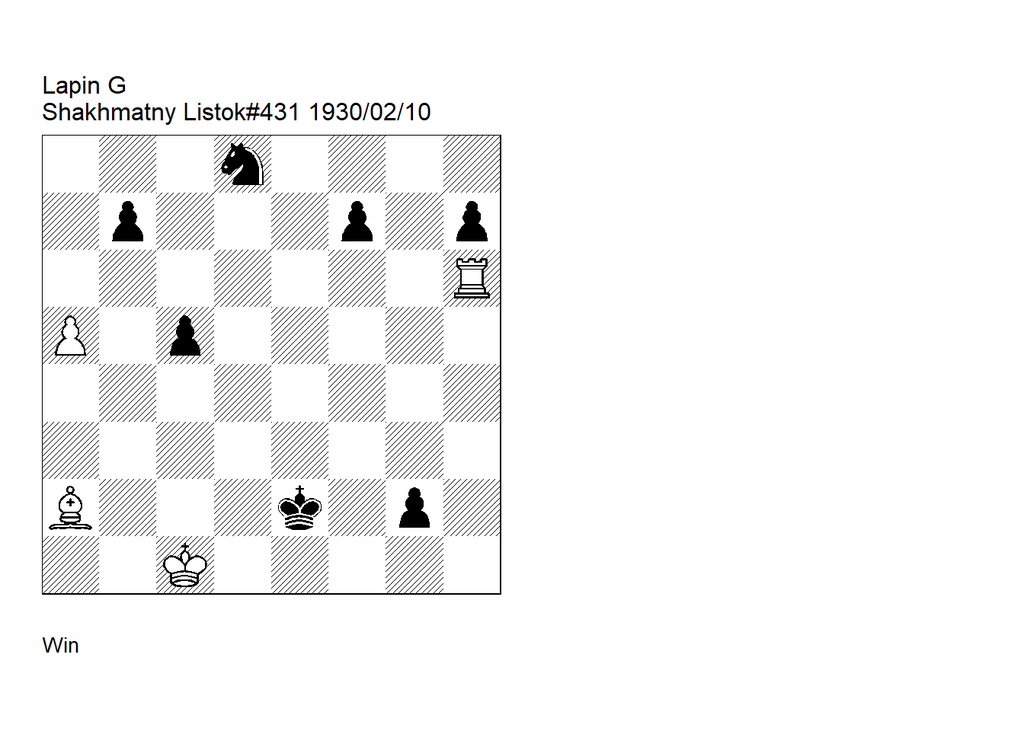

GBR: +0113.15c1e2 FEN: 3n4/1p3p1p/7R/P1p5/8/8/B3k1p1/2K5 w - - 0 1

**Shakhmatny Listok=3 . correction: Garcia=M Estudios Artisticos de Ajedrez - VI-44 2012. U2: Neuenschwander=B beatochess 16/03/2024. 1. Rh2 Kf1 2. Kd2** (2. Bc4+? Kg1 3. Rxh7 (3. Rh5! cook BN e.g. 3… Kf2 4. Rf5+ Ke3 5. Rg5 Kf2 6. Bd5 g1=Q+ 7. Rxg1 Kxg1 8. Bxb7 Ne6 9. Kc2 +-) 3… Kf2 4. Rh2 Kg3 5. Rxg2+ Kxg2 6. Bd5+ Kf2 7. Bxb7 Ne6 8. Kd2 c4 9. Kc3 Nc5 10. Kxc4 Nxb7 11. a6 Nd6+ 12. Kc5 Nc8) **2… Kg1!** (2… c4 3. Bxc4+ Kg1 4. Rh3 Kf2 5. Bd5) **3. Rh3! Kf2 4. Bd5 g1=Q 5. Rf3+ Kg2 6. Rxf7+ Kg3 7. Rg7+ Kf2 8. Rxg1 Kxg1 9. Ke2** (9. Kc2 or ) **9… h5 10. Bxb7 Ne6 eg 11. a6 Nc7 12. a7 h4 13. Kd3 1-0**.

### Herbstman +4030.34a7h3 (1930). Cook?

Date: 2024, March 18

File: Herbstman1930.pgn

The study by Herbstman seems incorrect. After **3… Kg2! 4. h8=Q Qf2**, White’s advantage appears unconvincing.

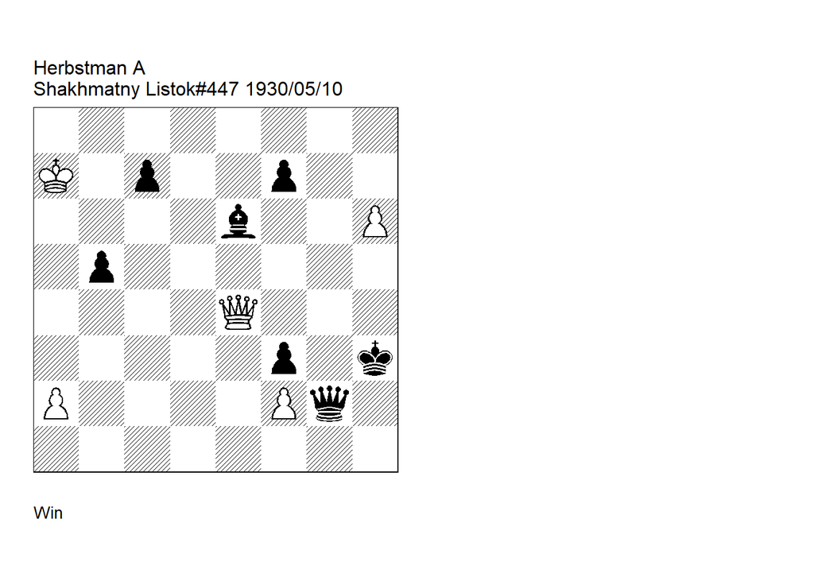

GBR: +4030.34a7h3 FEN: 8/K1p2p2/4b2P/1p6/4Q3/5p1k/P4Pq1/8 w - - 0 1

**Shakhmatny Listok=9. U3: Neuenschwander=B beatochess 18/03/2024 . 1. h7 Qxf2+ 2. Ka8 Qxa2+ 3. Kb8 Qb2** (3… Qa1 4. Qxf3+ Kh4 5. Qh1+! Qxh1 6. h8=Q+) (3… Kg2! cook BN 4. h8=Q Qf2! and it is unclear how White wins ) **4. Qxf3+ Kh4! 5. Qf4+! Kh5 6. Qh2+! Qxh2 7. h8=Q+ 1-0**.

### Grigoriev +0000.33e4f6 (1930). Dual

Date: 2024, March 18

File: Grigoriev1930.pgn

In Grigoriev’s study, **6. h8=Q+** is a dual.

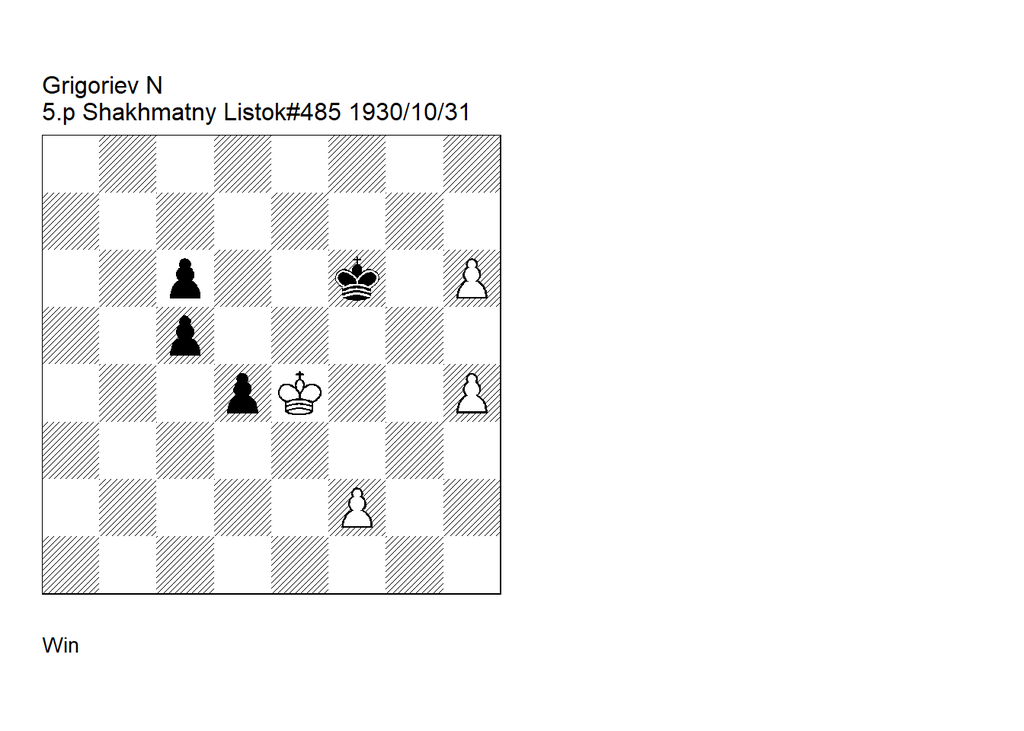

GBR: +0000.33e4f6 FEN: 8/8/2p2k1P/2p5/3pK2P/8/5P2/8 w - - 0 1

**Shakhmatny Listok=20.** (U2) **Neuenschwander=B beatochess 18/03/2024 . 1. h5! Kf7 2. f4! Kg8! 3. f5!** (3. Kd3? Kh8! 4. f5 Kh7 5. f6 Kxh6 6. Ke4 Kh7) **3… Kf7** (3… Kh7 4. f6! Kxh6 5. Kd3) (3… Kh8 4. f6) **4. Kd3!** (4. h7? Kg7 5. f6+ Kxh7 6. Kf5 d3 7. f7 d2! 8. f8=Q d1=Q 9. Qf7+ Kh8 10. Qe8+ Kh7!) **4… Kf6 5. h7! Kg7 6. f6+!** (6. Ke4? Kh8!) (6. h8=Q+! dual BN 6… Kxh8 7. f6 Kh7 8. Ke4 Kh6 9. Ke5 etc. main line ) **6… Kxh7 7. Ke4! Kh6** (7… Kg8 8. h6) **8. Kf5** (8. Ke5 or ) **8… d3! 9. f7 Kg7 10. Ke6 d2 11. h6+ Kg6** (11… Kf8 12. h7) **12. f8=Q d1=Q 13. Qg7+!** (13. Qf6+? Kh5 14. h7 Qd5+! 15. Ke7 Qe4+) **13… Kh5 14. h7! Qb3+** (14… Qe2+ 15. Qe5+) (14… Qd5+ 15. Ke7 Qe4+ 16. Kf8) **15. Kd6! Qb8+** (15… Qd5+ 16. Kc7) **16. Kxc6!** ( 16. Qc7? Qh8 17. Ke6 Kg6 18. Qg3+ Kh6!) (16. Kxc5? Qb5+ 17. Kd6 Qb4+ 18. Kc7 Qa5+ 19. Kb8 Qb5+) **16… Qc8+** (16… Qe8+ 17. Kc7!) **17. Kb6! Qb8+** ( 17… Qe6+ 18. Kc7!) (17… Qd8+ 18. Kb7! Qd5+ 19. Kc7!) **18. Kxc5** (18. Qb7? Qh8) **18… Qc8+ 19. Kb4!** (19. Kd4? Qd8+ 20. Kc4 Qc8+) **19… Qb8+ 20. Kc3! Qc8+ 21. Kd2! Qd8+ 22. Ke2! Qe8+ 23. Kf2! 1-0**.

### Gorgiev +0144.03c1e1 (1930). Correction

Date: 2024, March 18

File: Gorgiev1930.pgn

Gorgiev’s study can be corrected.

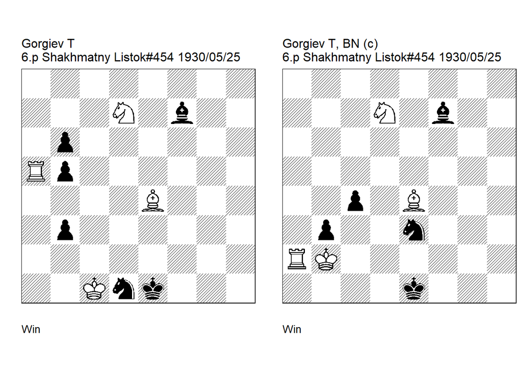

GBR: +0144.03c1e1 FEN: 8/3N1b2/1p6/Rp6/4B3/1p6/8/2Knk3 w - - 0 1

**Shakhmatny Listok=10 . U1: Van, der, Heijden=H HHdbVI 8-12-2016. 1. Ra7!** (1. Ra3? b4! 2. Ra7 b2+ 3. Kc2 Nc3) (1. Ra8! cook HH 1… b2+ 2. Kc2 b1=Q+ 3. Kxb1 Nc3+ 4. Kc2! Nxe4 5. Ne5 Bh5 6. Nd3+ Kf1 7. Ra1+ Kg2 8. Nf4+ Kg3 9. Nxh5+) **1… b2+ 2. Kc2! b1=Q+ 3. Kxb1 Nc3+ 4. Kc1! Nxe4 5. Nf6! Ng5** (5… Nxf6 6. Re7+ Ne4 (6… Be6 7. Rxe6+ Kf2 8. Rxf6+) (6… Kf2 7. Rxf7) 7. Rxe4+ Kf2 8. Rf4+) **6. Re7+** (6. Nh7? Nxh7 7. Re7+ Be6! 8. Rxe6+ Kf2 9. Rg6 Ke3!) **6… Be6!** (6… Kf2 main 7. Nh7! Nxh7 8. Rxf7+ Kg3 9. Rxh7) **7. Ne4! Nxe4 8. Rxe6 Kf2 9. Rxe4 1-0**.

GBR: +0144.02b2e1 FEN: 8/3N1b2/8/8/2p1B3/1p2n3/RK6/4k3 w - - 0 1

**correction: Neuenschwander=B beatochess 18/03/2024. 1. Ra7** (1. Ra8? Nd1+ 2. Kc1 b2+ 3. Kc2 b1=Q+ 4. Kxb1 Nc3+ 5. Kc2 Nxe4) **1… Nd1+ 2. Kc1 b2+ 3. Kc2** (3. Kb1? Nc3+ 4. Kxb2 Nxe4 5. Nf6 Ng5 6. Re7+ Kd2) **3… b1=Q+ 4. Kxb1 Nc3+ 5. Kc1 Nxe4 6. Nf6! Ng5** (6… Nxf6 7. Re7+! Ne4 (7… Kf2 8. Rxf7) (7… Be6 8. Rxe6+ Kf2 9. Rxf6+) 8. Rxe4+ Kf2 9. Rf4+) **7. Re7+!** (7. Nh7? Nxh7 8. Re7+ Be6! (8… Kf2? 9. Rxf7+ Ke3 10. Rxh7) ) **7… Be6** (7… Kf2 main 8. Nh7! Nxh7 9. Rxf7+ Ke3 10. Rxh7) **8. Ne4! Nxe4 9. Rxe6 Kf2 10. Rxe4 1-0**.

Date: 2024, March 20

File: Korolkov1930.pgn

At the end Black has a clear advantage after **7…. Rh2+! Kxh2 8. Bxa8**.

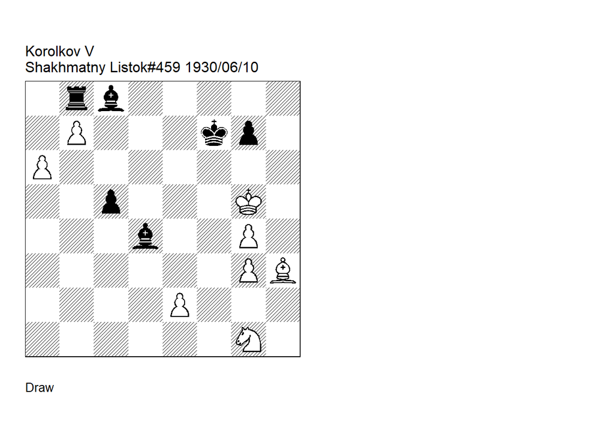

GBR: =0371.52g5f7 FEN: 1rb5/1P3kp1/P7/2p3K1/3b2P1/6PB/4P3/6N1 w - - 0 1

**Shakhmatny Listok=11. U3: Neuenschwander=B beatochess 20/03/2024. 1. a7 Be3+ 2. Kh4 Kf6! 3. Bf1! Rxb7 4. a8=Q g5+ 5. Kh3 Rh7+ 6. Kg2 Bb7+ 7. Nf3 Bxa8** ( 7… Rh2+! cook BN 8. Kxh2 Bxa8 -/+) **1/2-1/2**.

Date: 2024, March 20

File: Korolkov1929.pgn

In Korolkov’s study’ **1. Qg4** is a dual because the probably intended **1… Bc2** is not sufficient for a Black advantage. Adding a black pawn on a4 corrects the study..

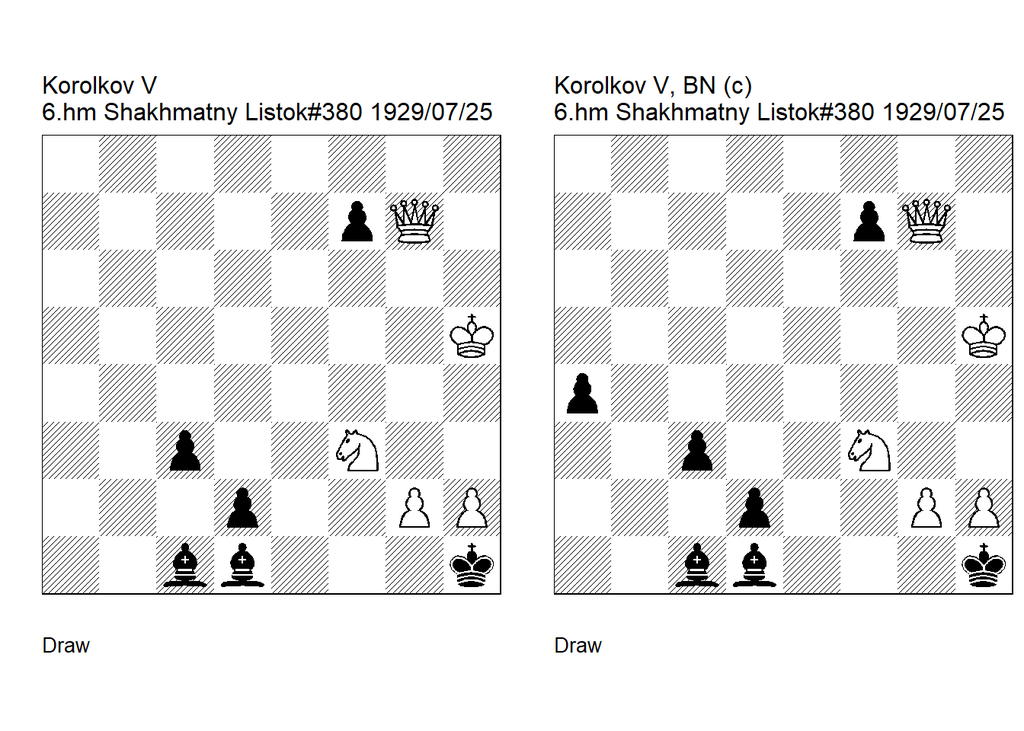

GBR: =1061.23h5h1 FEN: 8/5pQ1/8/7K/8/2p2N2/3p2PP/2bb3k w - - 0 1

**correction Neuenschwander=B beatochess 20/03/2024. 1. Qg3 c2 2. h4 Bxf3+ 3. Qxf3 d1=Q 4. g4+ Qxf3 1/2-1/2**.